# Elsevier 2022 SDG mapping

# General to all SDGs

## Introduction

The United Nations Sustainable Development Goals (SDGs) challenge the global community to build a world where no one is left behind.

Since 2018, Elsevier has generated SDG search queries to help researchers and institutions track and demonstrate progress toward the SDG targets. In the past 3 years, these queries, along with the university’s own data and evidence supporting progress and contributions to the particular SDG outside of research-based metrics, are used for the THE Impact Rankings.

## Method

For 2022, this SDG uses the exact same search query and ML algorithm as the Elsevier 2021 SDG mapping. [Full details of the 2021 methodology are available on Digital Commons Data.](https://elsevier.digitalcommonsdata.com/datasets/9sxdykm8s4/4)

# [SDG 9 - Build resilient infrastructure, promote inclusive and sustainable industrialization and foster innovation](https://sdgs.un.org/goals/goal9)

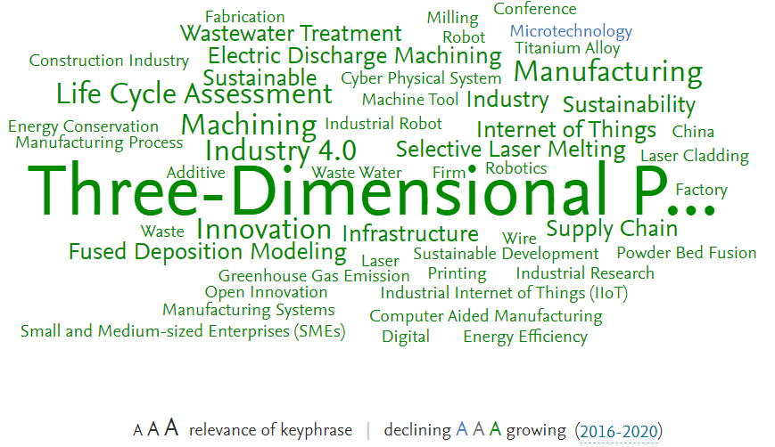

Explore this wordcloud plus the most active contributors on the [SciVal SDG site](https://scival.com/sdg)

## Query

Below is the full search query used for this SDG. We’ve broken it down by each query component. Use the + and – to concatenate the different bracket levels.

(

(

(

(

TITLE-ABS("infrastructure") OR TITLE-ABS("infrastructures")

)

AND TITLE-ABS

(

"Lower carbon"

)

)

OR

(

(

AUTHKEY("infrastructure") OR AUTHKEY("infrastructures")

)

AND AUTHKEY

(

"Lower carbon"

)

)

OR TITLE-ABS

(

"road development"

)

OR AUTHKEY

(

"road development"

)

OR TITLE-ABS

(

"Infrastructure construction project"

)

OR AUTHKEY

(

"Infrastructure construction project"

)

OR

(

TITLE-ABS

(

"improved Infrastructures"

)

OR TITLE-ABS

(

"improved Infrastructure"

)

)

OR

(

AUTHKEY

(

"improved Infrastructures"

)

OR AUTHKEY

(

"improved Infrastructure"

)

)

OR TITLE-ABS

(

"Road asset"

)

OR AUTHKEY

(

"Road asset"

)

OR TITLE-ABS

(

"highway infrastructures"

)

OR AUTHKEY

(

"highway infrastructures"

)

OR

(

TITLE-ABS

(

"transportation facilities"

)

AND TITLE-ABS

(

"sustainable"

)

)

OR

(

AUTHKEY

(

"transportation facilities"

)

AND AUTHKEY

(

"sustainable"

)

)

OR TITLE-ABS

(

"infrastructure system"

)

OR AUTHKEY

(

"infrastructure system"

)

OR TITLE-ABS

(

"railway infrastructure"

)

OR AUTHKEY

(

"railway infrastructure"

)

OR TITLE-ABS

(

"infrastructure investments"

)

OR AUTHKEY

(

"infrastructure investments"

)

OR

(

TITLE-ABS

(

"resiliency of infrastructure"

)

OR TITLE-ABS

(

"resiliency of infrastructures"

)

)

OR

(

AUTHKEY

(

"resiliency of infrastructure"

)

OR AUTHKEY

(

"resiliency of infrastructures"

)

)

OR

(

TITLE-ABS

(

"improved rural Infrastructures"

)

OR TITLE-ABS

(

"improved rural Infrastructure"

)

)

OR

(

AUTHKEY

(

"improved rural Infrastructures"

)

OR AUTHKEY

(

"improved rural Infrastructure"

)

)

OR TITLE-ABS

(

"access to infrastructures"

)

OR AUTHKEY

(

"access to infrastructures"

)

OR

(

(

TITLE-ABS("infrastructure") OR TITLE-ABS("infrastructures")

)

AND

(

TITLE-ABS("investment") OR TITLE-ABS("investments")

)

)

OR

(

(

AUTHKEY("infrastructure") OR AUTHKEY("infrastructures")

)

AND

(

AUTHKEY("investment") OR AUTHKEY("investments")

)

)

OR

(

TITLE-ABS

(

"terrestrial infrastructure"

)

OR TITLE-ABS

(

"terrestrial infrastructures"

)

)

OR

(

AUTHKEY

(

"terrestrial infrastructure"

)

OR AUTHKEY

(

"terrestrial infrastructures"

)

)

OR

(

TITLE-ABS

(

"pavements"

)

AND TITLE-ABS

(

"Sustainable development"

)

)

OR

(

AUTHKEY

(

"pavements"

)

AND AUTHKEY

(

"Sustainable development"

)

)

OR

(

TITLE-ABS

(

"quality of infrastructure"

)

OR TITLE-ABS

(

"quality of infrastructures"

)

)

OR

(

AUTHKEY

(

"quality of infrastructure"

)

OR AUTHKEY

(

"quality of infrastructures"

)

)

OR TITLE-ABS

(

"railroad infrastructures"

)

OR AUTHKEY

(

"railroad infrastructures"

)

OR TITLE-ABS

(

"Infrastructure policies"

)

OR AUTHKEY

(

"Infrastructure policies"

)

OR

(

TITLE-ABS

(

"infrastructure reliability"

)

OR TITLE-ABS

(

"infrastructures reliability"

)

)

OR

(

AUTHKEY

(

"infrastructure reliability"

)

OR AUTHKEY

(

"infrastructures reliability"

)

)

OR

(

TITLE-ABS

(

"public transport"

)

AND TITLE-ABS

(

"Infrastructure"

)

)

OR

(

AUTHKEY

(

"public transport"

)

AND AUTHKEY

(

"Infrastructure"

)

)

OR TITLE-ABS

(

"municipal Infrastructures"

)

OR AUTHKEY

(

"municipal Infrastructures"

)

OR TITLE-ABS

(

"Infrastructure asset"

)

OR AUTHKEY

(

"Infrastructure asset"

)

OR TITLE-ABS

(

"investment in infrastructures"

)

OR AUTHKEY

(

"investment in infrastructures"

)

OR TITLE-ABS

(

"pavement infrastructure"

)

OR AUTHKEY

(

"pavement infrastructure"

)

OR TITLE-ABS

(

"access to infrastructure"

)

OR AUTHKEY

(

"access to infrastructure"

)

OR

(

TITLE-ABS

(

"quality infrastructure"

)

OR TITLE-ABS

(

"quality infrastructures"

)

)

OR

(

AUTHKEY

(

"quality infrastructure"

)

OR AUTHKEY

(

"quality infrastructures"

)

)

OR

(

TITLE-ABS

(

"public transport service"

)

AND TITLE-ABS

(

"Infrastructure"

)

)

OR

(

AUTHKEY

(

"public transport service"

)

AND AUTHKEY

(

"Infrastructure"

)

)

OR TITLE-ABS

(

"integrated* public* transport*"

)

OR AUTHKEY

(

"integrated* public* transport*"

)

OR

(

TITLE-ABS

(

"infrastructure* development*"

)

AND TITLE-ABS

(

"Sustainab*"

)

)

OR

(

AUTHKEY

(

"infrastructure* development*"

)

AND AUTHKEY

(

"Sustainab*"

)

)

OR TITLE-ABS

(

"water infrastructure"

)

OR AUTHKEY

(

"water infrastructure"

)

OR TITLE-ABS

(

"urban* public* transportation*"

)

OR AUTHKEY

(

"urban* public* transportation*"

)

OR

(

(

TITLE-ABS("infrastructure") OR TITLE-ABS("infrastructures")

)

AND

(

TITLE-ABS("financing") OR TITLE-ABS("investing")

)

)

OR

(

(

AUTHKEY("infrastructure") OR AUTHKEY("infrastructures")

)

AND

(

AUTHKEY("financing") OR AUTHKEY("investing")

)

)

OR TITLE-ABS

(

"Transportation infrastructure"

)

OR AUTHKEY

(

"Transportation infrastructure"

)

OR TITLE-ABS

(

"public transport services"

)

OR AUTHKEY

(

"public transport services"

)

OR

(

TITLE-ABS

(

"terrestrial infrastructure"

)

OR TITLE-ABS

(

"terrestrial infrastructures"

)

)

OR

(

AUTHKEY

(

"terrestrial infrastructure"

)

OR AUTHKEY

(

"terrestrial infrastructures"

)

)

OR TITLE-ABS

(

"affordable infrastructures"

)

OR AUTHKEY

(

"affordable infrastructures"

)

OR TITLE-ABS

(

"Sustainable urban infrastructures"

)

OR AUTHKEY

(

"Sustainable urban infrastructures"

)

OR

(

TITLE-ABS

(

"sustainable infrastructure"

)

OR TITLE-ABS

(

"sustainable infrastructures"

)

)

OR

(

AUTHKEY

(

"sustainable infrastructure"

)

OR AUTHKEY

(

"sustainable infrastructures"

)

)

OR

(

(

TITLE-ABS("infrastructure") OR TITLE-ABS("infrastructures")

)

AND TITLE-ABS

(

"resiliency"

)

)

OR

(

(

AUTHKEY("infrastructure") OR AUTHKEY("infrastructures")

)

AND AUTHKEY

(

"resiliency"

)

)

OR

(

TITLE-ABS

(

"smart infrastructure"

)

OR TITLE-ABS

(

"smart infrastructures"

)

)

OR

(

AUTHKEY

(

"smart infrastructure"

)

OR AUTHKEY

(

"smart infrastructures"

)

)

OR

(

(

TITLE-ABS("rural Infrastructures") OR TITLE-ABS("rural Infrastructure")

)

AND TITLE-ABS

(

"development"

)

)

OR

(

(

AUTHKEY("rural Infrastructures") OR AUTHKEY("rural Infrastructure")

)

AND AUTHKEY

(

"development"

)

)

OR TITLE-ABS

(

"Development of Transport Infrastructure"

)

OR AUTHKEY

(

"Development of Transport Infrastructure"

)

OR TITLE-ABS

(

"infrastructure investment"

)

OR AUTHKEY

(

"infrastructure investment"

)

OR

(

TITLE-ABS

(

"marine infrastructure"

)

OR TITLE-ABS

(

"marine infrastructures"

)

)

OR

(

AUTHKEY

(

"marine infrastructure"

)

OR AUTHKEY

(

"marine infrastructures"

)

)

OR

(

(

TITLE-ABS("road planning") OR TITLE-ABS("road development") OR TITLE-ABS("road management")

)

AND TITLE-ABS

(

"Sustainable"

)

)

OR

(

(

AUTHKEY("road planning") OR AUTHKEY("road development") OR AUTHKEY("road management")

)

AND AUTHKEY

(

"Sustainable"

)

)

OR TITLE-ABS

(

"water infrastructures"

)

OR AUTHKEY

(

"water infrastructures"

)

OR

(

TITLE-ABS

(

"development of infrastructure"

)

AND TITLE-ABS

(

"Sustainab*"

)

)

OR

(

AUTHKEY

(

"development of infrastructure"

)

AND AUTHKEY

(

"Sustainab*"

)

)

OR TITLE-ABS

(

"infrastructure protection"

)

OR AUTHKEY

(

"infrastructure protection"

)

OR

(

(

TITLE-ABS("railway") OR TITLE-ABS("railways")

)

AND TITLE-ABS

(

"transport"

)

AND TITLE-ABS

(

"Sustainable"

)

)

OR

(

(

AUTHKEY("railway") OR AUTHKEY("railways")

)

AND AUTHKEY

(

"transport"

)

AND AUTHKEY

(

"Sustainable"

)

)

OR TITLE-ABS

(

"efficient* public* transport*"

)

OR AUTHKEY

(

"efficient* public* transport*"

)

OR TITLE-ABS

(

"transport Infrastructures"

)

OR AUTHKEY

(

"transport Infrastructures"

)

OR TITLE-ABS

(

"infrastructure sustainability"

)

OR AUTHKEY

(

"infrastructure sustainability"

)

OR

(

(

TITLE-ABS("infrastructure") OR TITLE-ABS("infrastructures")

)

AND TITLE-ABS

(

"Lower carbon"

)

)

OR

(

(

AUTHKEY("infrastructure") OR AUTHKEY("infrastructures")

)

AND AUTHKEY

(

"Lower carbon"

)

)

OR TITLE-ABS

(

"highway infrastructure"

)

OR AUTHKEY

(

"highway infrastructure"

)

OR TITLE-ABS

(

"Development of Transportation Infrastructure"

)

OR AUTHKEY

(

"Development of Transportation Infrastructure"

)

OR

(

TITLE-ABS

(

"transportation facility"

)

AND TITLE-ABS

(

"sustainable"

)

)

OR

(

AUTHKEY

(

"transportation facility"

)

AND AUTHKEY

(

"sustainable"

)

)

OR

(

(

TITLE-ABS("highway project") OR TITLE-ABS("highway Improvement")

)

AND TITLE-ABS

(

"Sustainable"

)

)

OR

(

(

AUTHKEY("highway project") OR AUTHKEY("highway Improvement")

)

AND AUTHKEY

(

"Sustainable"

)

)

OR

(

(

TITLE-ABS("road network") OR TITLE-ABS("road networks")

)

AND TITLE-ABS

(

"Sustainable"

)

)

OR

(

(

AUTHKEY("road network") OR AUTHKEY("road networks")

)

AND AUTHKEY

(

"Sustainable"

)

)

OR TITLE-ABS

(

"Roads infrastructures"

)

OR AUTHKEY

(

"Roads infrastructures"

)

OR

(

(

TITLE-ABS("infrastructure management") OR TITLE-ABS("infrastructures management")

)

AND TITLE-ABS

(

"resilient"

)

)

OR

(

(

AUTHKEY("infrastructure management") OR AUTHKEY("infrastructures management")

)

AND AUTHKEY

(

"resilient"

)

)

OR

(

TITLE-ABS

(

"resilient infrastructure"

)

OR TITLE-ABS

(

"resilient infrastructures"

)

)

OR

(

AUTHKEY

(

"resilient infrastructure"

)

OR AUTHKEY

(

"resilient infrastructures"

)

)

OR

(

TITLE-ABS

(

"public infrastructure"

)

OR TITLE-ABS

(

"public infrastructures"

)

)

OR

(

AUTHKEY

(

"public infrastructure"

)

OR AUTHKEY

(

"public infrastructures"

)

)

OR

(

TITLE-ABS

(

"infrastructure resilience"

)

OR TITLE-ABS

(

"infrastructures resilience"

)

)

OR

(

AUTHKEY

(

"infrastructure resilience"

)

OR AUTHKEY

(

"infrastructures resilience"

)

)

OR TITLE-ABS

(

"Infrastructure construction projects"

)

OR AUTHKEY

(

"Infrastructure construction projects"

)

OR

(

TITLE-ABS

(

"road investment"

)

OR TITLE-ABS

(

"road investments"

)

)

OR

(

AUTHKEY

(

"road investment"

)

OR AUTHKEY

(

"road investments"

)

)

OR TITLE-ABS

(

"railroad infrastructure"

)

OR AUTHKEY

(

"railroad infrastructure"

)

OR TITLE-ABS

(

"road management"

)

OR AUTHKEY

(

"road management"

)

OR TITLE-ABS

(

"Infrastructure reliability"

)

OR AUTHKEY

(

"Infrastructure reliability"

)

OR TITLE-ABS

(

"wastewater Infrastructure"

)

OR AUTHKEY

(

"wastewater Infrastructure"

)

OR

(

(

TITLE-ABS("highway transport") OR TITLE-ABS("highway transportation") OR TITLE-ABS("highway construction")

)

AND TITLE-ABS

(

"Sustainable"

)

)

OR

(

(

AUTHKEY("highway transport") OR AUTHKEY("highway transportation") OR AUTHKEY("highway construction")

)

AND AUTHKEY

(

"Sustainable"

)

)

OR TITLE-ABS

(

"transport Infrastructure"

)

OR AUTHKEY

(

"transport Infrastructure"

)

OR TITLE-ABS

(

"infrastructure projects"

)

OR AUTHKEY

(

"infrastructure projects"

)

OR

(

TITLE-ABS

(

"green infrastructure"

)

OR TITLE-ABS

(

"green infrastructures"

)

)

OR

(

AUTHKEY

(

"green infrastructure"

)

OR AUTHKEY

(

"green infrastructures"

)

)

OR TITLE-ABS

(

"Roads infrastructure"

)

OR AUTHKEY

(

"Roads infrastructure"

)

OR TITLE-ABS

(

"investment in infrastructure"

)

OR AUTHKEY

(

"investment in infrastructure"

)

OR

(

TITLE-ABS

(

"improved Infrastructures"

)

OR TITLE-ABS

(

"improved Infrastructure"

)

)

OR

(

AUTHKEY

(

"improved Infrastructures"

)

OR AUTHKEY

(

"improved Infrastructure"

)

)

OR TITLE-ABS

(

"public transport service"

)

OR AUTHKEY

(

"public transport service"

)

OR

(

(

TITLE-ABS("infrastructure") OR TITLE-ABS("infrastructures")

)

AND TITLE-ABS

(

"sustainable"

)

AND TITLE-ABS

(

"development"

)

)

OR

(

(

AUTHKEY("infrastructure") OR AUTHKEY("infrastructures")

)

AND AUTHKEY

(

"sustainable"

)

AND AUTHKEY

(

"development"

)

)

OR TITLE-ABS

(

"urban infrastructure"

)

OR AUTHKEY

(

"urban infrastructure"

)

OR TITLE-ABS

(

"public* transport* system*"

)

OR AUTHKEY

(

"public* transport* system*"

)

OR TITLE-ABS

(

"affordable infrastructure"

)

OR AUTHKEY

(

"affordable infrastructure"

)

OR

(

TITLE-ABS

(

"infrastructure sustainability"

)

OR TITLE-ABS

(

"infrastructures sustainability"

)

)

OR

(

AUTHKEY

(

"infrastructure sustainability"

)

OR AUTHKEY

(

"infrastructures sustainability"

)

)

OR TITLE-ABS

(

"railway infrastructures"

)

OR AUTHKEY

(

"railway infrastructures"

)

OR TITLE-ABS

(

"Intelligent* public* transport*"

)

OR AUTHKEY

(

"Intelligent* public* transport*"

)

OR TITLE-ABS

(

"sustainable freight"

)

OR AUTHKEY

(

"sustainable freight"

)

OR

(

(

TITLE-ABS("infrastructure management") OR TITLE-ABS("infrastructures management")

)

AND TITLE-ABS

(

"Sustainable"

)

)

OR

(

(

AUTHKEY("infrastructure management") OR AUTHKEY("infrastructures management")

)

AND AUTHKEY

(

"Sustainable"

)

)

OR

(

TITLE-ABS

(

"reliable infrastructure"

)

OR TITLE-ABS

(

"reliable infrastructures"

)

)

OR

(

AUTHKEY

(

"reliable infrastructure"

)

OR AUTHKEY

(

"reliable infrastructures"

)

)

OR TITLE-ABS

(

"freight infrastructure"

)

OR AUTHKEY

(

"freight infrastructure"

)

OR TITLE-ABS

(

"transantiago*"

)

OR AUTHKEY

(

"transantiago*"

)

OR

(

TITLE-ABS

(

"improved rural Infrastructures"

)

OR TITLE-ABS

(

"improved rural Infrastructure"

)

)

OR

(

AUTHKEY

(

"improved rural Infrastructures"

)

OR AUTHKEY

(

"improved rural Infrastructure"

)

)

OR TITLE-ABS

(

"Development of Transport Infrastructures"

)

OR AUTHKEY

(

"Development of Transport Infrastructures"

)

OR TITLE-ABS

(

"pavement infrastructures"

)

OR AUTHKEY

(

"pavement infrastructures"

)

OR TITLE-ABS

(

"infrastructure systems"

)

OR AUTHKEY

(

"infrastructure systems"

)

OR TITLE-ABS

(

"investments in infrastructure"

)

OR AUTHKEY

(

"investments in infrastructure"

)

OR TITLE-ABS

(

"Road infrastructure"

)

OR AUTHKEY

(

"Road infrastructure"

)

OR

(

(

TITLE-ABS("road pavement") OR TITLE-ABS("sustainable pavement") OR TITLE-ABS("road pavements") OR TITLE-ABS("sustainable pavements")

)

AND TITLE-ABS

(

"Sustainable"

)

)

OR

(

(

AUTHKEY("road pavement") OR AUTHKEY("sustainable pavement") OR AUTHKEY("road pavements") OR AUTHKEY("sustainable pavements")

)

AND AUTHKEY

(

"Sustainable"

)

)

OR TITLE-ABS

(

"Road assets"

)

OR AUTHKEY

(

"Road assets"

)

OR

(

(

TITLE-ABS("infrastructure") OR TITLE-ABS("infrastructures")

)

AND TITLE-ABS

(

"resilience"

)

)

OR

(

(

AUTHKEY("infrastructure") OR AUTHKEY("infrastructures")

)

AND AUTHKEY

(

"resilience"

)

)

OR

(

TITLE-ABS

(

"pavement"

)

AND TITLE-ABS

(

"Sustainable development"

)

)

OR

(

AUTHKEY

(

"pavement"

)

AND AUTHKEY

(

"Sustainable development"

)

)

OR

(

(

TITLE-ABS("road transport") OR TITLE-ABS("road transportation") OR TITLE-ABS("road construction")

)

AND TITLE-ABS

(

"Sustainable"

)

)

OR

(

(

AUTHKEY("road transport") OR AUTHKEY("road transportation") OR AUTHKEY("road construction")

)

AND AUTHKEY

(

"Sustainable"

)

)

OR

(

(

TITLE-ABS("railroad") OR TITLE-ABS("railroads") OR TITLE-ABS("rail")

)

AND TITLE-ABS

(

"transport"

)

AND TITLE-ABS

(

"Sustainable"

)

)

OR

(

(

AUTHKEY("railroad") OR AUTHKEY("railroads") OR AUTHKEY("rail")

)

AND AUTHKEY

(

"transport"

)

AND AUTHKEY

(

"Sustainable"

)

)

OR

(

(

TITLE-ABS("highway network") OR TITLE-ABS("highway networks") OR TITLE-ABS("highway planning") OR TITLE-ABS("highway development") OR TITLE-ABS("highway management")

)

AND TITLE-ABS

(

"Sustainable"

)

)

OR

(

(

AUTHKEY("highway network") OR AUTHKEY("highway networks") OR AUTHKEY("highway planning") OR AUTHKEY("highway development") OR AUTHKEY("highway management")

)

AND AUTHKEY

(

"Sustainable"

)

)

OR TITLE-ABS

(

"municipal Infrastructure"

)

OR AUTHKEY

(

"municipal Infrastructure"

)

OR

(

TITLE-ABS

(

"sustainable bridges"

)

OR TITLE-ABS

(

"sustainable bridge"

)

)

OR

(

AUTHKEY

(

"sustainable bridges"

)

OR AUTHKEY

(

"sustainable bridge"

)

)

OR TITLE-ABS

(

"Development of Transportation Infrastructures"

)

OR AUTHKEY

(

"Development of Transportation Infrastructures"

)

OR TITLE-ABS

(

"infrastructure management"

)

OR AUTHKEY

(

"infrastructure management"

)

OR TITLE-ABS

(

"global infrastructure"

)

OR AUTHKEY

(

"global infrastructure"

)

OR TITLE-ABS

(

"investments in infrastructures"

)

OR AUTHKEY

(

"investments in infrastructures"

)

OR TITLE-ABS

(

"Road asset management"

)

OR AUTHKEY

(

"Road asset management"

)

OR TITLE-ABS

(

"Road infrastructures"

)

OR AUTHKEY

(

"Road infrastructures"

)

OR TITLE-ABS

(

"infrastructure planning"

)

OR AUTHKEY

(

"infrastructure planning"

)

OR TITLE-ABS

(

"Smart* public* transport*"

)

OR AUTHKEY

(

"Smart* public* transport*"

)

OR TITLE-ABS

(

"public transport network"

)

OR AUTHKEY

(

"public transport network"

)

OR TITLE-ABS

(

"Sustainable urban infrastructure"

)

OR AUTHKEY

(

"Sustainable urban infrastructure"

)

OR

(

TITLE-ABS

(

"resilient urban infrastructure"

)

OR TITLE-ABS

(

"resilient urban infrastructures"

)

OR TITLE-ABS

(

"resilient rural infrastructure"

)

OR TITLE-ABS

(

"resilient rural infrastructures"

)

)

OR

(

AUTHKEY

(

"resilient urban infrastructure"

)

OR AUTHKEY

(

"resilient urban infrastructures"

)

OR AUTHKEY

(

"resilient rural infrastructure"

)

OR AUTHKEY

(

"resilient rural infrastructures"

)

)

OR

(

(

TITLE-ABS("rural Infrastructures") OR TITLE-ABS("rural Infrastructure")

)

AND TITLE-ABS

(

"development"

)

)

OR

(

(

AUTHKEY("rural Infrastructures") OR AUTHKEY("rural Infrastructure")

)

AND AUTHKEY

(

"development"

)

)

OR TITLE-ABS

(

"infrastructure sustainability"

)

OR AUTHKEY

(

"infrastructure sustainability"

)

OR TITLE-ABS

(

"wastewater Infrastructures"

)

OR AUTHKEY

(

"wastewater Infrastructures"

)

OR TITLE-ABS

(

"infrastructure project"

)

OR AUTHKEY

(

"infrastructure project"

)

OR TITLE-ABS

(

"Infrastructure assets"

)

OR AUTHKEY

(

"Infrastructure assets"

)

OR

(

(

TITLE-ABS("infrastructure") OR TITLE-ABS("infrastructures")

)

AND TITLE-ABS

(

"Sustainable Future"

)

)

OR

(

(

AUTHKEY("infrastructure") OR AUTHKEY("infrastructures")

)

AND AUTHKEY

(

"Sustainable Future"

)

)

OR TITLE-ABS

(

"Infrastructure asset management"

)

OR AUTHKEY

(

"Infrastructure asset management"

)

OR

(

TITLE-ABS

(

"infrastructure quality"

)

OR TITLE-ABS

(

"infrastructure quality"

)

)

OR

(

AUTHKEY

(

"infrastructure quality"

)

OR AUTHKEY

(

"infrastructure quality"

)

)

OR TITLE-ABS

(

"Transportation infrastructures"

)

OR AUTHKEY

(

"Transportation infrastructures"

)

OR TITLE-ABS

(

"Infrastructure policy"

)

OR AUTHKEY

(

"Infrastructure policy"

)

OR TITLE-ABS

(

"urban infrastructures"

)

OR AUTHKEY

(

"urban infrastructures"

)

)

)

OR

(

(

TITLE-ABS

(

"Digital Divide"

)

OR AUTHKEY

(

"Digital Divide"

)

OR

(

TITLE-ABS

(

"affordable access"

)

AND TITLE-ABS

(

"broadband services"

)

)

OR

(

AUTHKEY

(

"affordable access"

)

AND AUTHKEY

(

"broadband services"

)

)

OR

(

TITLE-ABS

(

"access to cellular networks"

)

OR TITLE-ABS

(

"access to cellular network"

)

)

OR

(

AUTHKEY

(

"access to cellular networks"

)

OR AUTHKEY

(

"access to cellular network"

)

)

OR TITLE-ABS

(

"ICT4D"

)

OR AUTHKEY

(

"ICT4D"

)

OR

(

TITLE-ABS

(

"communication technology infrastructure"

)

OR TITLE-ABS

(

"communication technology infrastructures"

)

)

OR

(

AUTHKEY

(

"communication technology infrastructure"

)

OR AUTHKEY

(

"communication technology infrastructures"

)

)

OR

(

TITLE-ABS

(

"affordable smartphone"

)

OR TITLE-ABS

(

"affordable smartphones"

)

)

OR

(

AUTHKEY

(

"affordable smartphone"

)

OR AUTHKEY

(

"affordable smartphones"

)

)

OR

(

TITLE-ABS

(

"affordable mobile device"

)

OR TITLE-ABS

(

"affordable mobile devices"

)

)

OR

(

AUTHKEY

(

"affordable mobile device"

)

OR AUTHKEY

(

"affordable mobile devices"

)

)

OR TITLE-ABS

(

"Telecommunications Act"

)

OR AUTHKEY

(

"Telecommunications Act"

)

OR

(

TITLE-ABS

(

"access to high-speed broadband"

)

OR TITLE-ABS

(

"access to highspeed broadband"

)

)

OR

(

AUTHKEY

(

"access to high-speed broadband"

)

OR AUTHKEY

(

"access to highspeed broadband"

)

)

OR

(

TITLE-ABS

(

"Telecommunications regulation"

)

OR TITLE-ABS

(

"Telecommunications regulations"

)

)

OR

(

AUTHKEY

(

"Telecommunications regulation"

)

OR AUTHKEY

(

"Telecommunications regulations"

)

)

OR TITLE-ABS

(

"Communications Technologies for Development"

)

OR AUTHKEY

(

"Communications Technologies for Development"

)

OR TITLE-ABS

(

"access to 4G"

)

OR AUTHKEY

(

"access to 4G"

)

OR TITLE-ABS

(

"access to advanced information"

)

OR AUTHKEY

(

"access to advanced information"

)

OR TITLE-ABS

(

"national broadband plan"

)

OR AUTHKEY

(

"national broadband plan"

)

OR TITLE-ABS

(

"telecommunication access"

)

OR AUTHKEY

(

"telecommunication access"

)

OR

(

TITLE-ABS

(

"access to internet"

)

OR TITLE-ABS

(

"access to the internet"

)

)

OR

(

AUTHKEY

(

"access to internet"

)

OR AUTHKEY

(

"access to the internet"

)

)

OR TITLE-ABS

(

"access to information and communication"

)

OR AUTHKEY

(

"access to information and communication"

)

OR TITLE-ABS

(

" broadband access"

)

OR AUTHKEY

(

" broadband access"

)

OR

(

TITLE-ABS

(

"3G coverage"

)

OR TITLE-ABS

(

"4G coverage"

)

OR TITLE-ABS

(

"5G coverage"

)

)

OR

(

AUTHKEY

(

"3G coverage"

)

OR AUTHKEY

(

"4G coverage"

)

OR AUTHKEY

(

"5G coverage"

)

)

OR TITLE-ABS

(

"Internet access"

)

OR AUTHKEY

(

"Internet access"

)

OR TITLE-ABS

(

"provision of Internet"

)

OR AUTHKEY

(

"provision of Internet"

)

OR TITLE-ABS

(

"Mobile access to information"

)

OR AUTHKEY

(

"Mobile access to information"

)

OR

(

TITLE-ABS

(

"affordable access"

)

AND TITLE-ABS

(

"internet"

)

)

OR

(

AUTHKEY

(

"affordable access"

)

AND AUTHKEY

(

"internet"

)

)

OR TITLE-ABS

(

"access to computers"

)

OR AUTHKEY

(

"access to computers"

)

OR TITLE-ABS

(

"free online access"

)

OR AUTHKEY

(

"free online access"

)

OR TITLE-ABS

(

"communication technology accessibility"

)

OR AUTHKEY

(

"communication technology accessibility"

)

OR TITLE-ABS

(

"access to communications technology"

)

OR AUTHKEY

(

"access to communications technology"

)

OR

(

(

TITLE-ABS("low-cost smartphone") OR TITLE-ABS("low-cost smartphones")

)

OR

(

TITLE-ABS("lowcost smartphone") OR TITLE-ABS("low-cost smartphones")

)

)

OR

(

(

AUTHKEY("low-cost smartphone") OR AUTHKEY("low-cost smartphones")

)

OR

(

AUTHKEY("lowcost smartphone") OR AUTHKEY("low-cost smartphones")

)

)

OR

(

TITLE-ABS

(

"global connectivity"

)

AND

(

TITLE-ABS("internet") OR TITLE-ABS("web") OR TITLE-ABS("telecommunication") OR TITLE-ABS("telecommunications") OR TITLE-ABS("phones") OR TITLE-ABS("phone") OR TITLE-ABS("mobile communication")

)

)

OR

(

AUTHKEY

(

"global connectivity"

)

AND

(

AUTHKEY("internet") OR AUTHKEY("web") OR AUTHKEY("telecommunication") OR AUTHKEY("telecommunications") OR AUTHKEY("phones") OR AUTHKEY("phone") OR AUTHKEY("mobile communication")

)

)

OR TITLE-ABS

(

"access to information technologies"

)

OR AUTHKEY

(

"access to information technologies"

)

OR TITLE-ABS

(

"information poverty"

)

OR AUTHKEY

(

"information poverty"

)

OR TITLE-ABS

(

"access to ICT"

)

OR AUTHKEY

(

"access to ICT"

)

OR

(

TITLE-ABS

(

"Low-cost mobile phone"

)

OR TITLE-ABS

(

"Lowcost mobile phone"

)

)

OR

(

AUTHKEY

(

"Low-cost mobile phone"

)

OR AUTHKEY

(

"Lowcost mobile phone"

)

)

OR TITLE-ABS

(

"Communication Technology for Development"

)

OR AUTHKEY

(

"Communication Technology for Development"

)

OR TITLE-ABS

(

"reliable ICT"

)

OR AUTHKEY

(

"reliable ICT"

)

OR TITLE-ABS

(

"affordable communications"

)

OR AUTHKEY

(

"affordable communications"

)

OR TITLE-ABS

(

"internet accessibility"

)

OR AUTHKEY

(

"internet accessibility"

)

OR TITLE-ABS

(

" broadband wireless access"

)

OR AUTHKEY

(

" broadband wireless access"

)

OR TITLE-ABS

(

"web access"

)

OR AUTHKEY

(

"web access"

)

OR TITLE-ABS

(

"access to telecommunication"

)

OR AUTHKEY

(

"access to telecommunication"

)

OR TITLE-ABS

(

"mobile phone infrastructure"

)

OR AUTHKEY

(

"mobile phone infrastructure"

)

OR

(

TITLE-ABS

(

"universal service obligation"

)

AND

(

TITLE-ABS("telecommunications") OR TITLE-ABS("telecommunication")

)

)

OR

(

AUTHKEY

(

"universal service obligation"

)

AND

(

AUTHKEY("telecommunications") OR AUTHKEY("telecommunication")

)

)

OR TITLE-ABS

(

"digital inequality"

)

OR AUTHKEY

(

"digital inequality"

)

OR TITLE-ABS

(

"Rural broadband"

)

OR AUTHKEY

(

"Rural broadband"

)

OR

(

TITLE-ABS

(

"telecommunications access"

)

OR TITLE-ABS

(

"telecommunications access"

)

)

OR

(

AUTHKEY

(

"telecommunications access"

)

OR AUTHKEY

(

"telecommunications access"

)

)

OR

(

TITLE-ABS

(

"affordable access"

)

AND TITLE-ABS

(

"telecommunication"

)

)

OR

(

AUTHKEY

(

"affordable access"

)

AND AUTHKEY

(

"telecommunication"

)

)

OR TITLE-ABS

(

"ICT infrastructures"

)

OR AUTHKEY

(

"ICT infrastructures"

)

OR TITLE-ABS

(

"access to broadband"

)

OR AUTHKEY

(

"access to broadband"

)

OR TITLE-ABS

(

"digital inequalities"

)

OR AUTHKEY

(

"digital inequalities"

)

OR TITLE-ABS

(

"access to 3G"

)

OR AUTHKEY

(

"access to 3G"

)

OR

(

TITLE-ABS

(

"Access to information"

)

AND TITLE-ABS

(

"internet"

)

)

OR

(

AUTHKEY

(

"Access to information"

)

AND AUTHKEY

(

"internet"

)

)

OR TITLE-ABS

(

"national broadband plans"

)

OR AUTHKEY

(

"national broadband plans"

)

OR

(

TITLE-ABS

(

"Low-cost phone"

)

OR TITLE-ABS

(

"Lowcost phone"

)

)

OR

(

AUTHKEY

(

"Low-cost phone"

)

OR AUTHKEY

(

"Lowcost phone"

)

)

OR TITLE-ABS

(

"Communications Technology for Development"

)

OR AUTHKEY

(

"Communications Technology for Development"

)

OR TITLE-ABS

(

"Open access to information"

)

OR AUTHKEY

(

"Open access to information"

)

OR

(

TITLE-ABS

(

"access to networked service"

)

OR TITLE-ABS

(

"access to networked services"

)

)

OR

(

AUTHKEY

(

"access to networked service"

)

OR AUTHKEY

(

"access to networked services"

)

)

OR TITLE-ABS

(

"improve internet"

)

OR AUTHKEY

(

"improve internet"

)

OR TITLE-ABS

(

"cost of mobile"

)

OR AUTHKEY

(

"cost of mobile"

)

OR TITLE-ABS

(

"Rural internet"

)

OR AUTHKEY

(

"Rural internet"

)

OR

(

TITLE-ABS

(

"internet access"

)

AND TITLE-ABS

(

"access to internet"

)

AND TITLE-ABS

(

"access to the internet"

)

)

OR

(

AUTHKEY

(

"internet access"

)

AND AUTHKEY

(

"access to internet"

)

AND AUTHKEY

(

"access to the internet"

)

)

OR

(

TITLE-ABS

(

"3G access"

)

OR TITLE-ABS

(

"4G access"

)

OR TITLE-ABS

(

"5G access"

)

)

OR

(

AUTHKEY

(

"3G access"

)

OR AUTHKEY

(

"4G access"

)

OR AUTHKEY

(

"5G access"

)

)

OR TITLE-ABS

(

"access to communications technologies"

)

OR AUTHKEY

(

"access to communications technologies"

)

OR

(

TITLE-ABS

(

"communication technology policies"

)

OR TITLE-ABS

(

"communication technology policy"

)

)

OR

(

AUTHKEY

(

"communication technology policies"

)

OR AUTHKEY

(

"communication technology policy"

)

)

OR TITLE-ABS

(

"ICT infrastructure"

)

OR AUTHKEY

(

"ICT infrastructure"

)

OR

(

TITLE-ABS

(

"public internet"

)

AND TITLE-ABS

(

"access"

)

)

OR

(

AUTHKEY

(

"public internet"

)

AND AUTHKEY

(

"access"

)

)

OR

(

TITLE-ABS

(

"low-cost Internet"

)

OR TITLE-ABS

(

"lowcost Internet"

)

)

OR

(

AUTHKEY

(

"low-cost Internet"

)

OR AUTHKEY

(

"lowcost Internet"

)

)

OR

(

TITLE-ABS

(

"universal access"

)

AND TITLE-ABS

(

"internet"

)

)

OR

(

AUTHKEY

(

"universal access"

)

AND AUTHKEY

(

"internet"

)

)

OR TITLE-ABS

(

"Communication Technologies for Development"

)

OR AUTHKEY

(

"Communication Technologies for Development"

)

OR TITLE-ABS

(

"ICT accessibility"

)

OR AUTHKEY

(

"ICT accessibility"

)

OR

(

TITLE-ABS

(

"mobile technologies"

)

AND TITLE-ABS

(

"infrastructures"

)

)

OR

(

AUTHKEY

(

"mobile technologies"

)

AND AUTHKEY

(

"infrastructures"

)

)

OR

(

TITLE-ABS

(

"Telecommunication policies"

)

OR TITLE-ABS

(

"Telecommunication policy"

)

)

OR

(

AUTHKEY

(

"Telecommunication policies"

)

OR AUTHKEY

(

"Telecommunication policy"

)

)

OR TITLE-ABS

(

"access to telecom"

)

OR AUTHKEY

(

"access to telecom"

)

OR

(

TITLE-ABS

(

"Access to and use of mobile"

)

OR TITLE-ABS

(

"Access to and use of the cellular"

)

)

OR

(

AUTHKEY

(

"Access to and use of mobile"

)

OR AUTHKEY

(

"Access to and use of the cellular"

)

)

OR TITLE-ABS

(

"affordable internet"

)

OR AUTHKEY

(

"affordable internet"

)

OR TITLE-ABS

(

"Internet wireless access"

)

OR AUTHKEY

(

"Internet wireless access"

)

OR

(

TITLE-ABS

(

"access to high-speed internet"

)

OR TITLE-ABS

(

"access to highspeed internet"

)

)

OR

(

AUTHKEY

(

"access to high-speed internet"

)

OR AUTHKEY

(

"access to highspeed internet"

)

)

OR TITLE-ABS

(

"broadband penetration"

)

OR AUTHKEY

(

"broadband penetration"

)

OR TITLE-ABS

(

"access to communication technology"

)

OR AUTHKEY

(

"access to communication technology"

)

OR

(

TITLE-ABS

(

"mobile network access"

)

OR TITLE-ABS

(

"mobile network accessibility"

)

OR TITLE-ABS

(

"access to mobile network"

)

)

OR

(

AUTHKEY

(

"mobile network access"

)

OR AUTHKEY

(

"mobile network accessibility"

)

OR AUTHKEY

(

"access to mobile network"

)

)

OR

(

TITLE-ABS

(

"Rural"

)

AND TITLE-ABS

(

"telecommunications"

)

)

OR

(

AUTHKEY

(

"Rural"

)

AND AUTHKEY

(

"telecommunications"

)

)

OR

(

TITLE-ABS

(

"public Wi-Fi"

)

OR TITLE-ABS

(

"public WiFi"

)

)

OR

(

AUTHKEY

(

"public Wi-Fi"

)

OR AUTHKEY

(

"public WiFi"

)

)

OR

(

TITLE-ABS

(

"global connectivity"

)

AND

(

TITLE-ABS("information and communication") OR TITLE-ABS("ICT")

)

)

OR

(

AUTHKEY

(

"global connectivity"

)

AND

(

AUTHKEY("information and communication") OR AUTHKEY("ICT")

)

)

OR TITLE-ABS

(

"access to information technology"

)

OR AUTHKEY

(

"access to information technology"

)

OR

(

TITLE-ABS

(

"cost of data"

)

AND TITLE-ABS

(

"mobile"

)

)

OR

(

AUTHKEY

(

"cost of data"

)

AND AUTHKEY

(

"mobile"

)

)

OR TITLE-ABS

(

"digital inclusion"

)

OR AUTHKEY

(

"digital inclusion"

)

OR TITLE-ABS

(

"internet penetration"

)

OR AUTHKEY

(

"internet penetration"

)

OR TITLE-ABS

(

"access to information technology"

)

OR AUTHKEY

(

"access to information technology"

)

OR

(

TITLE-ABS

(

"telecommunications infrastructures"

)

OR TITLE-ABS

(

"telecommunications infrastructure"

)

)

OR

(

AUTHKEY

(

"telecommunications infrastructures"

)

OR AUTHKEY

(

"telecommunications infrastructure"

)

)

OR TITLE-ABS

(

"digital inequalities"

)

OR AUTHKEY

(

"digital inequalities"

)

OR TITLE-ABS

(

"cheap internet"

)

OR AUTHKEY

(

"cheap internet"

)

OR

(

TITLE-ABS

(

"telecommunications accessibility"

)

OR TITLE-ABS

(

"telecommunications accessibility"

)

)

OR

(

AUTHKEY

(

"telecommunications accessibility"

)

OR AUTHKEY

(

"telecommunications accessibility"

)

)

OR TITLE-ABS

(

"mobile service provisioning"

)

OR AUTHKEY

(

"mobile service provisioning"

)

OR

(

TITLE-ABS

(

"Low-cost mobile phones"

)

OR TITLE-ABS

(

"Lowcost mobile phones"

)

)

OR

(

AUTHKEY

(

"Low-cost mobile phones"

)

OR AUTHKEY

(

"Lowcost mobile phones"

)

)

OR TITLE-ABS

(

"communication technology access"

)

OR AUTHKEY

(

"communication technology access"

)

OR

(

TITLE-ABS

(

"internet"

)

AND TITLE-ABS

(

"sustainable development"

)

)

OR

(

AUTHKEY

(

"internet"

)

AND AUTHKEY

(

"sustainable development"

)

)

OR TITLE-ABS

(

"Internet infrastructure"

)

OR AUTHKEY

(

"Internet infrastructure"

)

OR TITLE-ABS

(

"free broadband access"

)

OR AUTHKEY

(

"free broadband access"

)

OR

(

TITLE-ABS

(

"Telecommunication regulation"

)

OR TITLE-ABS

(

"Telecommunication regulations"

)

)

OR

(

AUTHKEY

(

"Telecommunication regulation"

)

OR AUTHKEY

(

"Telecommunication regulations"

)

)

OR TITLE-ABS

(

"ICT access"

)

OR AUTHKEY

(

"ICT access"

)

OR

(

TITLE-ABS

(

"internet coverage"

)

AND TITLE-ABS

(

"access"

)

)

OR

(

AUTHKEY

(

"internet coverage"

)

AND AUTHKEY

(

"access"

)

)

OR TITLE-ABS

(

"Rural telecommunications"

)

OR AUTHKEY

(

"Rural telecommunications"

)

OR TITLE-ABS

(

"Internet service provisioning"

)

OR AUTHKEY

(

"Internet service provisioning"

)

OR

(

TITLE-ABS

(

"telecommunication infrastructures"

)

OR TITLE-ABS

(

"telecommunication infrastructure"

)

)

OR

(

AUTHKEY

(

"telecommunication infrastructures"

)

OR AUTHKEY

(

"telecommunication infrastructure"

)

)

OR

(

TITLE-ABS

(

"internet service provider"

)

OR TITLE-ABS

(

"internet service providers"

)

OR TITLE-ABS

(

"internet service providing"

)

)

OR

(

AUTHKEY

(

"internet service provider"

)

OR AUTHKEY

(

"internet service providers"

)

OR AUTHKEY

(

"internet service providing"

)

)

OR

(

(

TITLE-ABS("e-inclusion") AND (TITLE-ABS("internet") OR TITLE-ABS("web"))

)

OR

(

TITLE-ABS("einclusion") AND (TITLE-ABS("internet") OR TITLE-ABS("web"))

)

)

OR

(

(

AUTHKEY("e-inclusion") AND (AUTHKEY("internet") OR AUTHKEY("web"))

)

OR

(

AUTHKEY("einclusion") AND (AUTHKEY("internet") OR AUTHKEY("web"))

)

)

OR

(

TITLE-ABS

(

"ICT policies"

)

OR TITLE-ABS

(

"ICT policy"

)

)

OR

(

AUTHKEY

(

"ICT policies"

)

OR AUTHKEY

(

"ICT policy"

)

)

OR TITLE-ABS

(

"access to communication technologies"

)

OR AUTHKEY

(

"access to communication technologies"

)

OR TITLE-ABS

(

"digital divide"

)

OR AUTHKEY

(

"digital divide"

)

OR

(

TITLE-ABS

(

"Access to and use of internet"

)

OR TITLE-ABS

(

"Access to and use of the internet"

)

)

OR

(

AUTHKEY

(

"Access to and use of internet"

)

OR AUTHKEY

(

"Access to and use of the internet"

)

)

OR

(

TITLE-ABS

(

"mobile networks access"

)

OR TITLE-ABS

(

"mobile networks accessibility"

)

OR TITLE-ABS

(

"access to mobile networks"

)

)

OR

(

AUTHKEY

(

"mobile networks access"

)

OR AUTHKEY

(

"mobile networks accessibility"

)

OR AUTHKEY

(

"access to mobile networks"

)

)

OR TITLE-ABS

(

"Robust ICT"

)

OR AUTHKEY

(

"Robust ICT"

)

OR

(

TITLE-ABS

(

"Telecommunication reform"

)

OR TITLE-ABS

(

"Telecommunication reforms"

)

OR TITLE-ABS

(

"Telecommunication reform"

)

OR TITLE-ABS

(

"Telecommunication reforms"

)

)

OR

(

AUTHKEY

(

"Telecommunication reform"

)

OR AUTHKEY

(

"Telecommunication reforms"

)

OR AUTHKEY

(

"Telecommunication reform"

)

OR AUTHKEY

(

"Telecommunication reforms"

)

)

OR

(

TITLE-ABS

(

"Telecommunications policies"

)

OR TITLE-ABS

(

"Telecommunications policy"

)

)

OR

(

AUTHKEY

(

"Telecommunications policies"

)

OR AUTHKEY

(

"Telecommunications policy"

)

)

OR TITLE-ABS

(

"Access and use of information"

)

OR AUTHKEY

(

"Access and use of information"

)

OR

(

TITLE-ABS

(

"Computerization"

)

AND

(

TITLE-ABS("school") OR TITLE-ABS("schools")

)

)

OR

(

AUTHKEY

(

"Computerization"

)

AND

(

AUTHKEY("school") OR AUTHKEY("schools")

)

)

OR TITLE-ABS

(

"access to 5G"

)

OR AUTHKEY

(

"access to 5G"

)

OR

(

(

TITLE-ABS("affordable smart-phone") OR TITLE-ABS("affordable smart-phones")

)

OR

(

TITLE-ABS("affordable smartphone") OR TITLE-ABS("affordable smart-phones")

)

)

OR

(

(

AUTHKEY("affordable smart-phone") OR AUTHKEY("affordable smart-phones")

)

OR

(

AUTHKEY("affordable smartphone") OR AUTHKEY("affordable smart-phones")

)

)

OR

(

(

TITLE-ABS("e-inclusion") AND (TITLE-ABS("applications") OR TITLE-ABS("accessibility") OR TITLE-ABS("computer") OR TITLE-ABS("telecommunication") OR TITLE-ABS("telecommunications "))

)

OR

(

TITLE-ABS("einclusion") AND (TITLE-ABS("applications") OR TITLE-ABS("accessibility") OR TITLE-ABS("computer") OR TITLE-ABS("telecommunication") OR TITLE-ABS("telecommunications "))

)

)

OR

(

(

AUTHKEY("e-inclusion") AND (AUTHKEY("applications") OR AUTHKEY("accessibility") OR AUTHKEY("computer") OR AUTHKEY("telecommunication") OR AUTHKEY("telecommunications "))

)

OR

(

AUTHKEY("einclusion") AND (AUTHKEY("applications") OR AUTHKEY("accessibility") OR AUTHKEY("computer") OR AUTHKEY("telecommunication") OR AUTHKEY("telecommunications "))

)

)

OR TITLE-ABS

(

"Internet infrastructures"

)

OR AUTHKEY

(

"Internet infrastructures"

)

OR

(

TITLE-ABS

(

"affordable access"

)

AND TITLE-ABS

(

"telecommunications"

)

)

OR

(

AUTHKEY

(

"affordable access"

)

AND AUTHKEY

(

"telecommunications"

)

)

OR

(

(

TITLE-ABS("smart-phone access and use") OR TITLE-ABS("phone access and use")

)

OR

(

TITLE-ABS("smartphone access and use") OR TITLE-ABS("phone access and use")

)

)

OR

(

(

AUTHKEY("smart-phone access and use") OR AUTHKEY("phone access and use")

)

OR

(

AUTHKEY("smartphone access and use") OR AUTHKEY("phone access and use")

)

)

OR TITLE-ABS

(

"communication technology access"

)

OR AUTHKEY

(

"communication technology access"

)

OR

(

TITLE-ABS

(

"Low-cost phones"

)

OR TITLE-ABS

(

"Lowcost phones"

)

)

OR

(

AUTHKEY

(

"Low-cost phones"

)

OR AUTHKEY

(

"Lowcost phones"

)

)

OR TITLE-ABS

(

"digital divides"

)

OR AUTHKEY

(

"digital divides"

)

OR

(

TITLE-ABS

(

"affordable mobile phone"

)

OR TITLE-ABS

(

"affordable mobile phones"

)

)

OR

(

AUTHKEY

(

"affordable mobile phone"

)

OR AUTHKEY

(

"affordable mobile phones"

)

)

OR TITLE-ABS

(

"free Internet"

)

OR AUTHKEY

(

"free Internet"

)

OR TITLE-ABS

(

"web accessibility"

)

OR AUTHKEY

(

"web accessibility"

)

OR TITLE-ABS

(

"Universal Telephone Service"

)

OR AUTHKEY

(

"Universal Telephone Service"

)

OR

(

TITLE-ABS

(

"internet policies"

)

OR TITLE-ABS

(

"internet policy"

)

)

OR

(

AUTHKEY

(

"internet policies"

)

OR AUTHKEY

(

"internet policy"

)

)

OR

(

TITLE-ABS

(

"access to network service"

)

OR TITLE-ABS

(

"access to network services"

)

)

OR

(

AUTHKEY

(

"access to network service"

)

OR AUTHKEY

(

"access to network services"

)

)

OR TITLE-ABS

(

"telecom access"

)

OR AUTHKEY

(

"telecom access"

)

OR

(

TITLE-ABS

(

"mobile users"

)

AND

(

TITLE-ABS("affordable") OR TITLE-ABS("inclusive") OR TITLE-ABS("universal") OR TITLE-ABS("quality") OR TITLE-ABS("reliable") OR TITLE-ABS("sustainable") OR TITLE-ABS("resilient") OR TITLE-ABS("clean") OR TITLE-ABS("efficient") OR TITLE-ABS("innovation")

)

)

OR

(

AUTHKEY

(

"mobile users"

)

AND

(

AUTHKEY("affordable") OR AUTHKEY("inclusive") OR AUTHKEY("universal") OR AUTHKEY("quality") OR AUTHKEY("reliable") OR AUTHKEY("sustainable") OR AUTHKEY("resilient") OR AUTHKEY("clean") OR AUTHKEY("efficient") OR AUTHKEY("innovation")

)

)

OR TITLE-ABS

(

"Rural wireless"

)

OR AUTHKEY

(

"Rural wireless"

)

)

)

OR

(

(

(

(

(TITLE-ABS("scientific development") OR TITLE-ABS("scientific developments")) AND (TITLE-ABS("industry") OR TITLE-ABS("industries") OR TITLE-ABS("industrial") OR TITLE-ABS("manufacturing"))

)

OR

(

(AUTHKEY("scientific development") OR AUTHKEY("scientific developments")) AND (AUTHKEY("industry") OR AUTHKEY("industries") OR AUTHKEY("industrial") OR AUTHKEY("manufacturing"))

)

OR TITLE-ABS

(

"global innovation index"

)

OR AUTHKEY

(

"global innovation index"

)

OR

(

(TITLE-ABS("technological innovation") OR TITLE-ABS("technological innovations")) AND (TITLE-ABS("industry") OR TITLE-ABS("industries") OR TITLE-ABS("industrial") OR TITLE-ABS("manufacturing"))

)

OR

(

(AUTHKEY("technological innovation") OR AUTHKEY("technological innovations")) AND (AUTHKEY("industry") OR AUTHKEY("industries") OR AUTHKEY("industrial") OR AUTHKEY("manufacturing"))

)

OR TITLE-ABS

(

"rapid manufacturing"

)

OR AUTHKEY

(

"rapid manufacturing"

)

OR

(

(TITLE-ABS("advanced technologies") OR TITLE-ABS("advanced technology")) AND (TITLE-ABS("industry") OR TITLE-ABS("industries") OR TITLE-ABS("industrial") OR TITLE-ABS("manufacturing"))

)

OR

(

(AUTHKEY("advanced technologies") OR AUTHKEY("advanced technology")) AND (AUTHKEY("industry") OR AUTHKEY("industries") OR AUTHKEY("industrial") OR AUTHKEY("manufacturing"))

)

OR

(

(TITLE-ABS("innovation policy") OR TITLE-ABS("innovation policies")) AND (TITLE-ABS("industry") OR TITLE-ABS("industries") OR TITLE-ABS("industrial") OR TITLE-ABS("manufacturing"))

)

OR

(

(AUTHKEY("innovation policy") OR AUTHKEY("innovation policies")) AND (AUTHKEY("industry") OR AUTHKEY("industries") OR AUTHKEY("industrial") OR AUTHKEY("manufacturing"))

)

OR

(

TITLE-ABS("technological progress") AND (TITLE-ABS("industry") OR TITLE-ABS("industries") OR TITLE-ABS("industrial") OR TITLE-ABS("manufacturing"))

)

OR

(

AUTHKEY("technological progress") AND (AUTHKEY("industry") OR AUTHKEY("industries") OR AUTHKEY("industrial") OR AUTHKEY("manufacturing"))

)

OR

(

TITLE-ABS("research and development") AND (TITLE-ABS("industry") OR TITLE-ABS("industries") OR TITLE-ABS("industrial") OR TITLE-ABS("manufacturing"))

)

OR

(

AUTHKEY("research and development") AND (AUTHKEY("industry") OR AUTHKEY("industries") OR AUTHKEY("industrial") OR AUTHKEY("manufacturing"))

)

OR

(

TITLE-ABS("industrial innovation") OR TITLE-ABS("industrial innovations") OR TITLE-ABS("industry innovation") OR TITLE-ABS("industry innovations")

)

OR

(

AUTHKEY("industrial innovation") OR AUTHKEY("industrial innovations") OR AUTHKEY("industry innovation") OR AUTHKEY("industry innovations")

)

OR

(

(TITLE-ABS("new technologies") OR TITLE-ABS("new technology")) AND (TITLE-ABS("industry") OR TITLE-ABS("industries") OR TITLE-ABS("industrial") OR TITLE-ABS("manufacturing"))

)

OR

(

(AUTHKEY("new technologies") OR AUTHKEY("new technology")) AND (AUTHKEY("industry") OR AUTHKEY("industries") OR AUTHKEY("industrial") OR AUTHKEY("manufacturing"))

)

OR

(

TITLE-ABS("R&D") AND (TITLE-ABS("industry") OR TITLE-ABS("industries") OR TITLE-ABS("industrial") OR TITLE-ABS("manufacturing"))

)

OR

(

AUTHKEY("R&D") AND (AUTHKEY("industry") OR AUTHKEY("industries") OR AUTHKEY("industrial") OR AUTHKEY("manufacturing"))

)

OR TITLE-ABS

(

"direct manufacturing"

)

OR AUTHKEY

(

"direct manufacturing"

)

OR

(

(TITLE-ABS("technological development") OR TITLE-ABS("technological developments")) AND (TITLE-ABS("industry") OR TITLE-ABS("industries") OR TITLE-ABS("industrial") OR TITLE-ABS("manufacturing"))

)

OR

(

(AUTHKEY("technological development") OR AUTHKEY("technological developments")) AND (AUTHKEY("industry") OR AUTHKEY("industries") OR AUTHKEY("industrial") OR AUTHKEY("manufacturing"))

)

OR

(

(TITLE-ABS("process innovation") OR TITLE-ABS("process innovations")) AND (TITLE-ABS("industry") OR TITLE-ABS("industries") OR TITLE-ABS("industrial") OR TITLE-ABS("manufacturing"))

)

OR

(

(AUTHKEY("process innovation") OR AUTHKEY("process innovations")) AND (AUTHKEY("industry") OR AUTHKEY("industries") OR AUTHKEY("industrial") OR AUTHKEY("manufacturing"))

)

OR TITLE-ABS

(

"communities of innovation"

)

OR AUTHKEY

(

"communities of innovation"

)

OR TITLE-ABS

(

"innovative manufacturing"

)

OR AUTHKEY

(

"innovative manufacturing"

)

OR

(

(TITLE-ABS("innovation") OR TITLE-ABS("innovative")) AND TITLE-ABS("industrialization")

)

OR

(

(AUTHKEY("innovation") OR AUTHKEY("innovative")) AND AUTHKEY("industrialization")

)

OR TITLE-ABS

(

"national innovation"

)

OR AUTHKEY

(

"national innovation"

)

OR TITLE-ABS

(

"fourth industrial revolution"

)

OR AUTHKEY

(

"fourth industrial revolution"

)

OR

(

(TITLE-ABS("innovation development") OR TITLE-ABS("innovation developments")) AND (TITLE-ABS("industry") OR TITLE-ABS("industries") OR TITLE-ABS("industrial") OR TITLE-ABS("manufacturing"))

)

OR

(

(AUTHKEY("innovation development") OR AUTHKEY("innovation developments")) AND (AUTHKEY("industry") OR AUTHKEY("industries") OR AUTHKEY("industrial") OR AUTHKEY("manufacturing"))

)

OR

(

(TITLE-ABS("advanced innovations") OR TITLE-ABS("product innovations") OR TITLE-ABS("inclusive innovations") OR TITLE-ABS("global innovations index") OR TITLE-ABS("national innovations") OR TITLE-ABS("model of innovations") OR TITLE-ABS("vertical innovations") OR TITLE-ABS("communities of innovations") OR TITLE-ABS("Eco-innovations") OR TITLE-ABS("disruptive innovations") OR TITLE-ABS("sustaining innovations")) OR (TITLE-ABS("advanced innovations") OR TITLE-ABS("product innovations") OR TITLE-ABS("inclusive innovations") OR TITLE-ABS("global innovations index") OR TITLE-ABS("national innovations") OR TITLE-ABS("model of innovations") OR TITLE-ABS("vertical innovations") OR TITLE-ABS("communities of innovations") OR TITLE-ABS("Ecoinnovations") OR TITLE-ABS("disruptive innovations") OR TITLE-ABS("sustaining innovations"))

)

OR

(

(AUTHKEY("advanced innovations") OR AUTHKEY("product innovations") OR AUTHKEY("inclusive innovations") OR AUTHKEY("global innovations index") OR AUTHKEY("national innovations") OR AUTHKEY("model of innovations") OR AUTHKEY("vertical innovations") OR AUTHKEY("communities of innovations") OR AUTHKEY("Eco-innovations") OR AUTHKEY("disruptive innovations") OR AUTHKEY("sustaining innovations")) OR (AUTHKEY("advanced innovations") OR AUTHKEY("product innovations") OR AUTHKEY("inclusive innovations") OR AUTHKEY("global innovations index") OR AUTHKEY("national innovations") OR AUTHKEY("model of innovations") OR AUTHKEY("vertical innovations") OR AUTHKEY("communities of innovations") OR AUTHKEY("Ecoinnovations") OR AUTHKEY("disruptive innovations") OR AUTHKEY("sustaining innovations"))

)

OR

(

(TITLE-ABS("novel technologies") OR TITLE-ABS("novel technology")) AND (TITLE-ABS("industry") OR TITLE-ABS("industries") OR TITLE-ABS("industrial") OR TITLE-ABS("manufacturing"))

)

OR

(

(AUTHKEY("novel technologies") OR AUTHKEY("novel technology")) AND (AUTHKEY("industry") OR AUTHKEY("industries") OR AUTHKEY("industrial") OR AUTHKEY("manufacturing"))

)

OR

(

TITLE-ABS("scientific progress") AND (TITLE-ABS("industry") OR TITLE-ABS("industries") OR TITLE-ABS("industrial") OR TITLE-ABS("manufacturing"))

)

OR

(

AUTHKEY("scientific progress") AND (AUTHKEY("industry") OR AUTHKEY("industries") OR AUTHKEY("industrial") OR AUTHKEY("manufacturing"))

)

OR

(

(TITLE-ABS("innovative process") OR TITLE-ABS("innovative processes")) AND (TITLE-ABS("industry") OR TITLE-ABS("industries") OR TITLE-ABS("industrial") OR TITLE-ABS("manufacturing"))

)

OR

(

(AUTHKEY("innovative process") OR AUTHKEY("innovative processes")) AND (AUTHKEY("industry") OR AUTHKEY("industries") OR AUTHKEY("industrial") OR AUTHKEY("manufacturing"))

)

OR

(

(TITLE-ABS("innovation") OR TITLE-ABS("innovative")) AND (TITLE-ABS("industry development") OR TITLE-ABS("industrial development") OR TITLE-ABS("manufacturing development"))

)

OR

(

(AUTHKEY("innovation") OR AUTHKEY("innovative")) AND (AUTHKEY("industry development") OR AUTHKEY("industrial development") OR AUTHKEY("manufacturing development"))

)

OR TITLE-ABS

(

"product innovation"

)

OR AUTHKEY

(

"product innovation"

)

OR TITLE-ABS

(

"vertical innovation"

)

OR AUTHKEY

(

"vertical innovation"

)

OR TITLE-ABS

(

"disruptive innovation"

)

OR AUTHKEY

(

"disruptive innovation"

)

OR

(

TITLE-ABS("R & D") AND (TITLE-ABS("industry") OR TITLE-ABS("industries") OR TITLE-ABS("industrial") OR TITLE-ABS("manufacturing"))

)

OR

(

AUTHKEY("R & D") AND (AUTHKEY("industry") OR AUTHKEY("industries") OR AUTHKEY("industrial") OR AUTHKEY("manufacturing"))

)

OR

(

(TITLE-ABS("research and development") OR TITLE-ABS("R&D") OR TITLE-ABS("innovative R & D")) AND (TITLE-ABS("agroindustry") OR TITLE-ABS("agroindustries") OR TITLE-ABS("agroindustrial") OR TITLE-ABS("refinery plant") OR TITLE-ABS("refinery plants") OR TITLE-ABS("automotive assembly") OR TITLE-ABS("production technology") OR TITLE-ABS("production technologies") OR TITLE-ABS("pulp and paper"))

)

OR

(

(AUTHKEY("research and development") OR AUTHKEY("R&D") OR AUTHKEY("innovative R & D")) AND (AUTHKEY("agroindustry") OR AUTHKEY("agroindustries") OR AUTHKEY("agroindustrial") OR AUTHKEY("refinery plant") OR AUTHKEY("refinery plants") OR AUTHKEY("automotive assembly") OR AUTHKEY("production technology") OR AUTHKEY("production technologies") OR AUTHKEY("pulp and paper"))

)

OR TITLE-ABS

(

"advanced manufacturing"

)

OR AUTHKEY

(

"advanced manufacturing"

)

OR

(

TITLE-ABS("Eco-innovation") OR TITLE-ABS("Ecoinnovation")

)

OR

(

AUTHKEY("Eco-innovation") OR AUTHKEY("Ecoinnovation")

)

OR TITLE-ABS

(

"additive manufacturing"

)

OR AUTHKEY

(

"additive manufacturing"

)

OR TITLE-ABS

(

"layered manufacturing"

)

OR AUTHKEY

(

"layered manufacturing"

)

OR TITLE-ABS

(

"industry 4.0"

)

OR AUTHKEY

(

"industry 4.0"

)

OR

(

(TITLE-ABS("innovative capacity") OR TITLE-ABS("innovative capacities")) AND (TITLE-ABS("industry") OR TITLE-ABS("industries") OR TITLE-ABS("industrial") OR TITLE-ABS("manufacturing"))

)

OR

(

(AUTHKEY("innovative capacity") OR AUTHKEY("innovative capacities")) AND (AUTHKEY("industry") OR AUTHKEY("industries") OR AUTHKEY("industrial") OR AUTHKEY("manufacturing"))

)

OR TITLE-ABS

(

"Integrated manufacturing"

)

OR AUTHKEY

(

"Integrated manufacturing"

)

OR TITLE-ABS

(

"efficient manufacturing"

)

OR AUTHKEY

(

"efficient manufacturing"

)

OR

(

(TITLE-ABS("scientific innovation") OR TITLE-ABS("scientific innovations")) AND (TITLE-ABS("industry") OR TITLE-ABS("industries") OR TITLE-ABS("industrial") OR TITLE-ABS("manufacturing"))

)

OR

(

(AUTHKEY("scientific innovation") OR AUTHKEY("scientific innovations")) AND (AUTHKEY("industry") OR AUTHKEY("industries") OR AUTHKEY("industrial") OR AUTHKEY("manufacturing"))

)

OR

(

TITLE-ABS("R and D") AND (TITLE-ABS("industry") OR TITLE-ABS("industries") OR TITLE-ABS("industrial") OR TITLE-ABS("manufacturing"))

)

OR

(

AUTHKEY("R and D") AND (AUTHKEY("industry") OR AUTHKEY("industries") OR AUTHKEY("industrial") OR AUTHKEY("manufacturing"))

)

OR TITLE-ABS

(

"new manufacturing"

)

OR AUTHKEY

(

"new manufacturing"

)

OR TITLE-ABS

(

"inclusive innovation"

)

OR AUTHKEY

(

"inclusive innovation"

)

OR TITLE-ABS

(

"digital manufacturing"

)

OR AUTHKEY

(

"digital manufacturing"

)

OR TITLE-ABS

(

"3D manufacturing"

)

OR AUTHKEY

(

"3D manufacturing"

)

OR

(

TITLE-ABS("process innovation") OR TITLE-ABS("process innovations")

)

OR

(

AUTHKEY("process innovation") OR AUTHKEY("process innovations")

)

OR

(

(TITLE-ABS("innovative technology") OR TITLE-ABS("innovative technologies")) AND (TITLE-ABS("industry") OR TITLE-ABS("industries") OR TITLE-ABS("industrial") OR TITLE-ABS("manufacturing"))

)

OR

(

(AUTHKEY("innovative technology") OR AUTHKEY("innovative technologies")) AND (AUTHKEY("industry") OR AUTHKEY("industries") OR AUTHKEY("industrial") OR AUTHKEY("manufacturing"))

)

OR

(

TITLE-ABS("innovation policy") OR TITLE-ABS("innovation policies")

)

OR

(

AUTHKEY("innovation policy") OR AUTHKEY("innovation policies")

)

OR TITLE-ABS

(

"flexible machining"

)

OR AUTHKEY

(

"flexible machining"

)

OR TITLE-ABS

(

"virtual manufacturing"

)

OR AUTHKEY

(

"virtual manufacturing"

)

OR

(

TITLE-ABS("new manufacturing technology") OR TITLE-ABS("new manufacturing technologies")

)

OR

(

AUTHKEY("new manufacturing technology") OR AUTHKEY("new manufacturing technologies")

)

OR

(

(TITLE-ABS("technological capability") OR TITLE-ABS("technological capabilities")) AND (TITLE-ABS("industry") OR TITLE-ABS("industries") OR TITLE-ABS("industrial") OR TITLE-ABS("manufacturing"))

)

OR

(

(AUTHKEY("technological capability") OR AUTHKEY("technological capabilities")) AND (AUTHKEY("industry") OR AUTHKEY("industries") OR AUTHKEY("industrial") OR AUTHKEY("manufacturing"))

)

OR TITLE-ABS

(

"Technological monitoring"

)

OR AUTHKEY

(

"Technological monitoring"

)

OR TITLE-ABS

(

"novel manufacturing"

)

OR AUTHKEY

(

"novel manufacturing"

)

OR TITLE-ABS

(

"cloud manufacturing"

)

OR AUTHKEY

(

"cloud manufacturing"

)

OR

(

TITLE-ABS("technological upgrading") AND (TITLE-ABS("industry") OR TITLE-ABS("industries") OR TITLE-ABS("industrial") OR TITLE-ABS("manufacturing"))

)

OR

(

AUTHKEY("technological upgrading") AND (AUTHKEY("industry") OR AUTHKEY("industries") OR AUTHKEY("industrial") OR AUTHKEY("manufacturing"))

)

OR TITLE-ABS

(

"technological capability"

)

OR AUTHKEY

(

"technological capability"

)

OR TITLE-ABS

(

"advanced process control"

)

OR AUTHKEY

(

"advanced process control"

)

OR

(

(TITLE-ABS("smart sensor") OR TITLE-ABS("smart sensors")) AND (TITLE-ABS("industry") OR TITLE-ABS("industries") OR TITLE-ABS("industrial") OR TITLE-ABS("manufacturing"))

)

OR

(

(AUTHKEY("smart sensor") OR AUTHKEY("smart sensors")) AND (AUTHKEY("industry") OR AUTHKEY("industries") OR AUTHKEY("industrial") OR AUTHKEY("manufacturing"))

)

OR TITLE-ABS

(

"model of innovation"

)

OR AUTHKEY

(

"model of innovation"

)

OR

(

TITLE-ABS("process control") AND TITLE-ABS("manufacturing")

)

OR

(

AUTHKEY("process control") AND AUTHKEY("manufacturing")

)

OR

(

(TITLE-ABS("innovative development") OR TITLE-ABS("innovative developments")) AND (TITLE-ABS("industry") OR TITLE-ABS("industries") OR TITLE-ABS("industrial") OR TITLE-ABS("manufacturing"))

)

OR

(

(AUTHKEY("innovative development") OR AUTHKEY("innovative developments")) AND (AUTHKEY("industry") OR AUTHKEY("industries") OR AUTHKEY("industrial") OR AUTHKEY("manufacturing"))

)

OR TITLE-ABS

(

"Open innovations"

)

OR AUTHKEY

(

"Open innovations"

)

OR TITLE-ABS

(

"cloud based manufacturing"

)

OR AUTHKEY

(

"cloud based manufacturing"

)

OR TITLE-ABS

(

"manufacturing IoT"

)

OR AUTHKEY

(

"manufacturing IoT"

)

OR

(

(TITLE-ABS("web of things") AND (TITLE-ABS("industry") OR TITLE-ABS("industries") OR TITLE-ABS("industrial") OR TITLE-ABS("manufacturing"))) AND NOT ((TITLE-ABS("home") OR TITLE-ABS("homes") OR TITLE-ABS("city") OR TITLE-ABS("cities") OR TITLE-ABS("buildings")))

)

OR

(

(AUTHKEY("web of things") AND (AUTHKEY("industry") OR AUTHKEY("industries") OR AUTHKEY("industrial") OR AUTHKEY("manufacturing"))) AND NOT ((AUTHKEY("home") OR AUTHKEY("homes") OR AUTHKEY("city") OR AUTHKEY("cities") OR AUTHKEY("buildings")))

)

OR TITLE-ABS

(

"advanced innovation"

)

OR AUTHKEY

(

"advanced innovation"

)

OR TITLE-ABS

(

"smart manufacturing"

)

OR AUTHKEY

(

"smart manufacturing"

)

OR

(

(TITLE-ABS("internet of things") AND (TITLE-ABS("industry") OR TITLE-ABS("industries") OR TITLE-ABS("industrial") OR TITLE-ABS("manufacturing"))) AND NOT ((TITLE-ABS("home") OR TITLE-ABS("homes") OR TITLE-ABS("city") OR TITLE-ABS("cities") OR TITLE-ABS("buildings")))

)

OR

(

(AUTHKEY("internet of things") AND (AUTHKEY("industry") OR AUTHKEY("industries") OR AUTHKEY("industrial") OR AUTHKEY("manufacturing"))) AND NOT ((AUTHKEY("home") OR AUTHKEY("homes") OR AUTHKEY("city") OR AUTHKEY("cities") OR AUTHKEY("buildings")))

)

OR

(

(TITLE-ABS("innovative activity") OR TITLE-ABS("innovative activities")) AND (TITLE-ABS("industry") OR TITLE-ABS("industries") OR TITLE-ABS("industrial") OR TITLE-ABS("manufacturing"))

)

OR

(

(AUTHKEY("innovative activity") OR AUTHKEY("innovative activities")) AND (AUTHKEY("industry") OR AUTHKEY("industries") OR AUTHKEY("industrial") OR AUTHKEY("manufacturing"))

)

OR

(

TITLE-ABS("advanced industrial applications") OR TITLE-ABS("advanced industrial application") OR TITLE-ABS("advanced industrial manufacturing") OR TITLE-ABS("advanced industrial technologies") OR TITLE-ABS("advanced industrial technology") OR TITLE-ABS("advanced industrial process") OR TITLE-ABS("advanced industrial processes")

)

OR

(

AUTHKEY("advanced industrial applications") OR AUTHKEY("advanced industrial application") OR AUTHKEY("advanced industrial manufacturing") OR AUTHKEY("advanced industrial technologies") OR AUTHKEY("advanced industrial technology") OR AUTHKEY("advanced industrial process") OR AUTHKEY("advanced industrial processes")

)

OR

(

TITLE-ABS("robot*") AND TITLE-ABS("industr* operation*")

)

OR

(

AUTHKEY("robot*") AND AUTHKEY("industr* operation*")

)

OR TITLE-ABS

(

"Automated manufacturing System"

)

OR AUTHKEY

(

"Automated manufacturing System"

)

OR TITLE-ABS

(

"fast prototyping"

)

OR AUTHKEY

(

"fast prototyping"

)

OR

(

TITLE-ABS("smart industries") OR TITLE-ABS("smart industry")

)

OR

(

AUTHKEY("smart industries") OR AUTHKEY("smart industry")

)

OR TITLE-ABS

(

"industry iot"

)

OR AUTHKEY

(

"industry iot"

)

OR TITLE-ABS

(

"sustaining innovation"

)

OR AUTHKEY

(

"sustaining innovation"

)

OR TITLE-ABS

(

"freeform fabrication"

)

OR AUTHKEY

(

"freeform fabrication"

)

OR

(

TITLE-ABS("Innovation and Development") AND (TITLE-ABS("industry") OR TITLE-ABS("industries") OR TITLE-ABS("industrial") OR TITLE-ABS("manufacturing"))

)

OR

(

AUTHKEY("Innovation and Development") AND (AUTHKEY("industry") OR AUTHKEY("industries") OR AUTHKEY("industrial") OR AUTHKEY("manufacturing"))

)

OR TITLE-ABS

(

"Factory automation"

)

OR AUTHKEY

(

"Factory automation"

)

OR

(

TITLE-ABS("ultra-precision manufacturing") OR TITLE-ABS("ultraprecision manufacturing")

)

OR

(

AUTHKEY("ultra-precision manufacturing") OR AUTHKEY("ultraprecision manufacturing")

)

OR TITLE-ABS

(

"Intelligent manufacturing"

)

OR AUTHKEY

(

"Intelligent manufacturing"

)

OR

(

(TITLE-ABS("intelligent sensor") OR TITLE-ABS("intelligent sensors")) AND (TITLE-ABS("industry") OR TITLE-ABS("industries") OR TITLE-ABS("industrial") OR TITLE-ABS("manufacturing"))

)

OR

(

(AUTHKEY("intelligent sensor") OR AUTHKEY("intelligent sensors")) AND (AUTHKEY("industry") OR AUTHKEY("industries") OR AUTHKEY("industrial") OR AUTHKEY("manufacturing"))

)

OR TITLE-ABS

(

"Open innovation"

)

OR AUTHKEY

(

"Open innovation"

)

OR

(

TITLE-ABS("advanced industrial technology") OR TITLE-ABS("advanced industrial technologies")

)

OR

(

AUTHKEY("advanced industrial technology") OR AUTHKEY("advanced industrial technologies")

)

OR TITLE-ABS

(

"technological capabilities"

)

OR AUTHKEY

(

"technological capabilities"

)

OR TITLE-ABS

(

"new machining"

)

OR AUTHKEY

(

"new machining"

)

OR

(

TITLE-ABS("machining technology") OR TITLE-ABS("machining technologies")

)

OR

(

AUTHKEY("machining technology") OR AUTHKEY("machining technologies")

)

OR

(

TITLE-ABS("industrial control systems") OR TITLE-ABS("industrial control system")

)

OR

(

AUTHKEY("industrial control systems") OR AUTHKEY("industrial control system")

)

OR TITLE-ABS

(

"additive manufacture"

)

OR AUTHKEY

(

"additive manufacture"

)

OR TITLE-ABS

(

"Virtual prototyping"

)

OR AUTHKEY

(

"Virtual prototyping"

)

OR TITLE-ABS

(

"industrial iot"

)

OR AUTHKEY

(

"industrial iot"

)

OR TITLE-ABS

(

"Automated manufacturing Systems"

)

OR AUTHKEY

(

"Automated manufacturing Systems"

)

OR TITLE-ABS

(

"novel machining"

)

OR AUTHKEY

(

"novel machining"

)

OR

(

TITLE-ABS("industrial process control") OR TITLE-ABS("industry process control") OR TITLE-ABS("industries process control")

)

OR

(

AUTHKEY("industrial process control") OR AUTHKEY("industry process control") OR AUTHKEY("industries process control")

)

OR

(

(TITLE-ABS("embedded sensor") OR TITLE-ABS("embedded sensors")) AND (TITLE-ABS("industry") OR TITLE-ABS("industries") OR TITLE-ABS("industrial") OR TITLE-ABS("manufacturing"))

)

OR

(

(AUTHKEY("embedded sensor") OR AUTHKEY("embedded sensors")) AND (AUTHKEY("industry") OR AUTHKEY("industries") OR AUTHKEY("industrial") OR AUTHKEY("manufacturing"))

)

OR TITLE-ABS

(

"Technological monitoring"

)

OR AUTHKEY

(

"Technological monitoring"

)

OR

(

TITLE-ABS("micro-fabrication") OR TITLE-ABS("microfabrication")

)

OR

(

AUTHKEY("micro-fabrication") OR AUTHKEY("microfabrication")

)

OR TITLE-ABS

(

"rapid prototyping"

)

OR AUTHKEY

(

"rapid prototyping"

)

OR TITLE-ABS

(

"discharge machining"

)

OR AUTHKEY

(

"discharge machining"

)

OR TITLE-ABS

(

"fast manufacturing"

)

OR AUTHKEY

(

"fast manufacturing"

)

OR

(

TITLE-ABS("innovative industrial process") OR TITLE-ABS("innovative industrial processes")

)

OR

(

AUTHKEY("innovative industrial process") OR AUTHKEY("innovative industrial processes")

)

OR TITLE-ABS

(

"flexible manufacturing"

)

OR AUTHKEY

(

"flexible manufacturing"

)

OR

(

TITLE-ABS("robot*") AND TITLE-ABS("industr* system*")

)

OR

(

AUTHKEY("robot*") AND AUTHKEY("industr* system*")

)

OR

(

TITLE-ABS("Computer-aided machining") OR TITLE-ABS("Computeraided machining")

)

OR

(

AUTHKEY("Computer-aided machining") OR AUTHKEY("Computeraided machining")

)

OR

(

TITLE-ABS("research spin-off") OR TITLE-ABS("research spinoff")

)

OR

(

AUTHKEY("research spin-off") OR AUTHKEY("research spinoff")

)

OR

(

TITLE-ABS("nano-machining") OR TITLE-ABS("nanomachining")

)

OR

(

AUTHKEY("nano-machining") OR AUTHKEY("nanomachining")

)

OR TITLE-ABS

(

"industry automation"

)

OR AUTHKEY

(

"industry automation"

)

OR TITLE-ABS

(

"smart factory"

)

OR AUTHKEY

(

"smart factory"

)

OR

(

TITLE-ABS("manufacturing innovation") OR TITLE-ABS("manufacturing innovations")

)

OR

(

AUTHKEY("manufacturing innovation") OR AUTHKEY("manufacturing innovations")

)

OR TITLE-ABS

(

"advanced machining"

)

OR AUTHKEY

(

"advanced machining"

)

OR TITLE-ABS

(

"automated machining"

)

OR AUTHKEY

(

"automated machining"

)

OR

(

TITLE-ABS("nano-architectonics") OR TITLE-ABS("nanoarchitectonics")

)

OR

(

AUTHKEY("nano-architectonics") OR AUTHKEY("nanoarchitectonics")

)

OR TITLE-ABS

(

"micro edm"

)

OR AUTHKEY

(

"micro edm"

)

OR

(

TITLE-ABS("Computer-aided manufacturing") OR TITLE-ABS("Computeraided manufacturing")

)

OR

(

AUTHKEY("Computer-aided manufacturing") OR AUTHKEY("Computeraided manufacturing")

)

OR TITLE-ABS

(

"smart factories"

)

OR AUTHKEY

(

"smart factories"

)

OR

(

TITLE-ABS("Micro-manufacturing") OR TITLE-ABS("Micromanufacturing")

)

OR

(

AUTHKEY("Micro-manufacturing") OR AUTHKEY("Micromanufacturing")

)

OR

(

TITLE-ABS("new industrial process") OR TITLE-ABS("new industrial processes")

)

OR

(

AUTHKEY("new industrial process") OR AUTHKEY("new industrial processes")

)

OR

(

(TITLE-ABS("Computer-aided design") AND TITLE-ABS("manufactur*")) OR (TITLE-ABS("Computeraided design") AND TITLE-ABS("manufactur*"))

)

OR

(

(AUTHKEY("Computer-aided design") AND AUTHKEY("manufactur*")) OR (AUTHKEY("Computeraided design") AND AUTHKEY("manufactur*"))

)

OR

(

TITLE-ABS("robotic") AND (TITLE-ABS("manufacturing system") OR TITLE-ABS("manufacturing systems"))

)

OR

(

AUTHKEY("robotic") AND (AUTHKEY("manufacturing system") OR AUTHKEY("manufacturing systems"))

)

OR

(

TITLE-ABS("manufacturing process") AND TITLE-ABS("sensors")

)

OR

(

AUTHKEY("manufacturing process") AND AUTHKEY("sensors")

)

OR TITLE-ABS

(

"Automatic Process control"

)

OR AUTHKEY

(

"Automatic Process control"

)

OR

(

TITLE-ABS("distributed control systems") OR TITLE-ABS("distributed control system")

)

OR

(

AUTHKEY("distributed control systems") OR AUTHKEY("distributed control system")

)

OR

(

TITLE-ABS("automated assembly systems") OR TITLE-ABS("automated assembly system")

)

OR

(

AUTHKEY("automated assembly systems") OR AUTHKEY("automated assembly system")

)

OR TITLE-ABS

(

"efficient machining"

)

OR AUTHKEY

(

"efficient machining"

)

OR

(

TITLE-ABS("nano-manufacturing") OR TITLE-ABS("nanomanufacturing")

)

OR

(

AUTHKEY("nano-manufacturing") OR AUTHKEY("nanomanufacturing")

)

OR

(

TITLE-ABS("CNC") AND (TITLE-ABS("machines") OR TITLE-ABS("machine") OR TITLE-ABS("machining"))

)

OR

(

AUTHKEY("CNC") AND (AUTHKEY("machines") OR AUTHKEY("machine") OR AUTHKEY("machining"))

)

OR TITLE-ABS

(

"Industrial Automation"

)

OR AUTHKEY

(

"Industrial Automation"

)

OR

(

(TITLE-ABS("electron-beam melting") OR TITLE-ABS("electron-beam selective melting")) OR (TITLE-ABS("electronbeam melting") OR TITLE-ABS("electron-beam selective melting"))

)

OR

(

(AUTHKEY("electron-beam melting") OR AUTHKEY("electron-beam selective melting")) OR (AUTHKEY("electronbeam melting") OR AUTHKEY("electron-beam selective melting"))

)

OR TITLE-ABS

(

"innovation knowledge"

)

OR AUTHKEY

(

"innovation knowledge"

)

OR

(

TITLE-ABS("cobot") OR TITLE-ABS("cobots") OR TITLE-ABS("Collaborative* mobile* robot*") OR TITLE-ABS("Collaborative* robot*") OR TITLE-ABS("Industrial* robot*")

)

OR

(

AUTHKEY("cobot") OR AUTHKEY("cobots") OR AUTHKEY("Collaborative* mobile* robot*") OR AUTHKEY("Collaborative* robot*") OR AUTHKEY("Industrial* robot*")

)

OR

(

TITLE-ABS("manufacturing technology") OR TITLE-ABS("manufacturing technologies") OR TITLE-ABS("manufacture technology") OR TITLE-ABS("manufacture technologies")

)

OR

(

AUTHKEY("manufacturing technology") OR AUTHKEY("manufacturing technologies") OR AUTHKEY("manufacture technology") OR AUTHKEY("manufacture technologies")

)

OR

(

TITLE-ABS("mixed-model assembly") OR TITLE-ABS("mixedmodel assembly")

)

OR

(

AUTHKEY("mixed-model assembly") OR AUTHKEY("mixedmodel assembly")

)

OR TITLE-ABS

(

"layer manufacturing"

)

OR AUTHKEY

(

"layer manufacturing"

)

OR

(

TITLE-ABS("robot*") AND TITLE-ABS("industr* application*")

)

OR

(

AUTHKEY("robot*") AND AUTHKEY("industr* application*")

)

OR TITLE-ABS

(

"additive fabrication"

)

OR AUTHKEY

(

"additive fabrication"

)

OR TITLE-ABS

(

"advanced prototyping"

)

OR AUTHKEY

(

"advanced prototyping"

)

OR

(

TITLE-ABS("robotics") AND (TITLE-ABS("manufacturing system") OR TITLE-ABS("manufacturing systems"))

)

OR

(

AUTHKEY("robotics") AND (AUTHKEY("manufacturing system") OR AUTHKEY("manufacturing systems"))

)

OR

(

TITLE-ABS("robot assembly system") OR TITLE-ABS("robot assembly systems")

)

OR

(

AUTHKEY("robot assembly system") OR AUTHKEY("robot assembly systems")

)

OR TITLE-ABS

(

"composite manufacturing"

)

OR AUTHKEY

(

"composite manufacturing"

)

OR

(

TITLE-ABS("CAD/CAM systems") OR TITLE-ABS("CAD/CAM system")

)

OR

(

AUTHKEY("CAD/CAM systems") OR AUTHKEY("CAD/CAM system")

)

OR

(

TITLE-ABS("new industrial technology") OR TITLE-ABS("new industrial technologies")

)

OR

(

AUTHKEY("new industrial technology") OR AUTHKEY("new industrial technologies")

)

OR

(

TITLE-ABS("Flexible robotic") OR TITLE-ABS("Flexible robotics")

)

OR

(

AUTHKEY("Flexible robotic") OR AUTHKEY("Flexible robotics")

)

OR TITLE-ABS

(

"fdm* process*"

)

OR AUTHKEY

(

"fdm* process*"

)

OR

(

TITLE-ABS("rapid* prototyp*") AND TITLE-ABS("manufactur*")

)

OR

(

AUTHKEY("rapid* prototyp*") AND AUTHKEY("manufactur*")

)

OR

(

TITLE-ABS("university spin-off") OR TITLE-ABS("university spinoff")

)

OR

(

AUTHKEY("university spin-off") OR AUTHKEY("university spinoff")

)

OR

(

TITLE-ABS("robotic cell") OR TITLE-ABS("robotic cells")

)

OR

(

AUTHKEY("robotic cell") OR AUTHKEY("robotic cells")

)

OR

(

TITLE-ABS("stereolithograph*") AND NOT ((TITLE-ABS("surgery") OR TITLE-ABS("surgical") OR TITLE-ABS("prosthesis") OR TITLE-ABS("Dental")))

)

OR

(

AUTHKEY("stereolithograph*") AND NOT ((AUTHKEY("surgery") OR AUTHKEY("surgical") OR AUTHKEY("prosthesis") OR AUTHKEY("Dental")))

)

OR

(

TITLE-ABS("micro-machining") OR TITLE-ABS("micromachining")

)

OR

(

AUTHKEY("micro-machining") OR AUTHKEY("micromachining")

)

OR

(

TITLE-ABS("Smart factory") OR TITLE-ABS("Smart factories")

)

OR

(

AUTHKEY("Smart factory") OR AUTHKEY("Smart factories")

)

OR

(

TITLE-ABS("mechatronic*") AND TITLE-ABS("manufacturing")

)

OR

(

AUTHKEY("mechatronic*") AND AUTHKEY("manufacturing")

)

OR

(

(TITLE-ABS("Computer-aided design") AND TITLE-ABS("industr*")) OR (TITLE-ABS("Computeraided design") AND TITLE-ABS("industr*"))

)

OR

(

(AUTHKEY("Computer-aided design") AND AUTHKEY("industr*")) OR (AUTHKEY("Computeraided design") AND AUTHKEY("industr*"))

)

OR TITLE-ABS

(

"powder bed fusion"

)

OR AUTHKEY

(

"powder bed fusion"

)

OR TITLE-ABS

(

"laser sintering"

)

OR AUTHKEY

(

"laser sintering"

)

OR

(

TITLE-ABS("CNC") AND TITLE-ABS("manufacturing")

)

OR

(

AUTHKEY("CNC") AND AUTHKEY("manufacturing")

)

OR TITLE-ABS

(

"industrial internet"

)

OR AUTHKEY

(

"industrial internet"

)

OR TITLE-ABS

(

"manufacturing automation"

)

OR AUTHKEY

(

"manufacturing automation"

)

OR

(

TITLE-ABS("fast-tool servo") OR TITLE-ABS("fasttool servo")

)

OR

(

AUTHKEY("fast-tool servo") OR AUTHKEY("fasttool servo")

)

OR TITLE-ABS

(

"rapid tooling"

)

OR AUTHKEY

(

"rapid tooling"

)

OR

(

(TITLE-ABS("innovation") OR TITLE-ABS("innovative")) AND TITLE-ABS("industrial")

)

OR

(

(AUTHKEY("innovation") OR AUTHKEY("innovative")) AND AUTHKEY("industrial")

)

OR TITLE-ABS

(

"Selective laser melting"

)

OR AUTHKEY

(

"Selective laser melting"

)

OR TITLE-ABS

(

"laser cladding"

)

OR AUTHKEY

(

"laser cladding"

)

OR

(

TITLE-ABS("cim system") OR TITLE-ABS("cim systems")

)

OR

(

AUTHKEY("cim system") OR AUTHKEY("cim systems")

)

OR TITLE-ABS

(

"Industrial Automation"

)

OR AUTHKEY

(

"Industrial Automation"

)

OR

(

TITLE-ABS("industr*") AND TITLE-ABS("iiot")

)

OR

(

AUTHKEY("industr*") AND AUTHKEY("iiot")

)

OR

(

(TITLE-ABS("Computer-aided design") AND (TITLE-ABS("industry") OR TITLE-ABS("industries") OR TITLE-ABS("industrial") OR TITLE-ABS("manufacturing") OR TITLE-ABS("CNC machine") OR TITLE-ABS("CNC machining") OR TITLE-ABS("CNC machines"))) OR (TITLE-ABS("Computeraided design") AND (TITLE-ABS("industry") OR TITLE-ABS("industries") OR TITLE-ABS("industrial") OR TITLE-ABS("manufacturing") OR TITLE-ABS("CNC machine") OR TITLE-ABS("CNC machining") OR TITLE-ABS("CNC machines")))

)

OR

(

(AUTHKEY("Computer-aided design") AND (AUTHKEY("industry") OR AUTHKEY("industries") OR AUTHKEY("industrial") OR AUTHKEY("manufacturing") OR AUTHKEY("CNC machine") OR AUTHKEY("CNC machining") OR AUTHKEY("CNC machines"))) OR (AUTHKEY("Computeraided design") AND (AUTHKEY("industry") OR AUTHKEY("industries") OR AUTHKEY("industrial") OR AUTHKEY("manufacturing") OR AUTHKEY("CNC machine") OR AUTHKEY("CNC machining") OR AUTHKEY("CNC machines")))

)

OR

(

(TITLE-ABS("CAD") OR TITLE-ABS("aided design")) AND TITLE-ABS("product design process")

)

OR

(

(AUTHKEY("CAD") OR AUTHKEY("aided design")) AND AUTHKEY("product design process")

)

OR

(

TITLE-ABS("Computer-aided Process planning") OR TITLE-ABS("Computeraided Process planning")

)

OR

(

AUTHKEY("Computer-aided Process planning") OR AUTHKEY("Computeraided Process planning")

)

OR TITLE-ABS

(

"flexible fabrication"

)

OR AUTHKEY

(

"flexible fabrication"

)

OR

(

TITLE-ABS("robotic machining") OR TITLE-ABS("robot machining")

)

OR

(

AUTHKEY("robotic machining") OR AUTHKEY("robot machining")

)

OR

(

TITLE-ABS("CAD/CAM") AND TITLE-ABS("manufactur*")

)

OR

(

AUTHKEY("CAD/CAM") AND AUTHKEY("manufactur*")

)

OR

(

TITLE-ABS("automated assembly line") OR TITLE-ABS("automated assembly lines")

)

OR

(

AUTHKEY("automated assembly line") OR AUTHKEY("automated assembly lines")

)

OR TITLE-ABS

(

"academic patenting"

)

OR AUTHKEY

(

"academic patenting"

)

OR

(

TITLE-ABS("ultra-precision machining") OR TITLE-ABS("ultraprecision machining")

)

OR

(

AUTHKEY("ultra-precision machining") OR AUTHKEY("ultraprecision machining")

)

OR

(

TITLE-ABS("robot*") AND (TITLE-ABS("manufacturing process") OR TITLE-ABS("manufacturing processes"))

)

OR

(

AUTHKEY("robot*") AND (AUTHKEY("manufacturing process") OR AUTHKEY("manufacturing processes"))

)

OR

(

(TITLE-ABS("innovation") OR TITLE-ABS("innovative")) AND TITLE-ABS("industries")

)

OR

(

(AUTHKEY("innovation") OR AUTHKEY("innovative")) AND AUTHKEY("industries")

)

OR TITLE-ABS

(

"novel machining"

)

OR AUTHKEY

(

"novel machining"

)

OR

(

TITLE-ABS("composite fabrication process") OR TITLE-ABS("composite fabrication technology") OR TITLE-ABS("composite fabrication processes") OR TITLE-ABS("composite fabrication technologies")

)

OR

(

AUTHKEY("composite fabrication process") OR AUTHKEY("composite fabrication technology") OR AUTHKEY("composite fabrication processes") OR AUTHKEY("composite fabrication technologies")

)

OR

(

(TITLE-ABS("robot*") AND TITLE-ABS("machining")) AND NOT ((TITLE-ABS("surgery") OR TITLE-ABS("surgical")))

)

OR

(

(AUTHKEY("robot*") AND AUTHKEY("machining")) AND NOT ((AUTHKEY("surgery") OR AUTHKEY("surgical")))

)

OR

(

TITLE-ABS("ultra-precision turning") OR TITLE-ABS("ultraprecision turning")

)

OR

(

AUTHKEY("ultra-precision turning") OR AUTHKEY("ultraprecision turning")

)

OR

(

(TITLE-ABS("mixed-model") AND (TITLE-ABS("assembly line") OR TITLE-ABS("assembly lines"))) OR (TITLE-ABS("mixedmodel") AND (TITLE-ABS("assembly line") OR TITLE-ABS("assembly lines")))

)

OR

(

(AUTHKEY("mixed-model") AND (AUTHKEY("assembly line") OR AUTHKEY("assembly lines"))) OR (AUTHKEY("mixedmodel") AND (AUTHKEY("assembly line") OR AUTHKEY("assembly lines")))

)

OR TITLE-ABS

(

"computer numerical control"

)

OR AUTHKEY

(

"computer numerical control"

)

OR

(

TITLE-ABS("fdm 3d") OR TITLE-ABS("fdm parts")

)

OR

(

AUTHKEY("fdm 3d") OR AUTHKEY("fdm parts")

)

OR

(

(TITLE-ABS("five-axis machine") OR TITLE-ABS("5-axis machine") OR TITLE-ABS("five-axis machines") OR TITLE-ABS("5-axis machines") OR TITLE-ABS("five-axis NC") OR TITLE-ABS("five-axis CNC") OR TITLE-ABS("5-axis NC") OR TITLE-ABS("5-axis CNC") OR TITLE-ABS("five-axis machining") OR TITLE-ABS("5-axis machining")) OR (TITLE-ABS("fiveaxis machine") OR TITLE-ABS("5-axis machine") OR TITLE-ABS("five-axis machines") OR TITLE-ABS("5-axis machines") OR TITLE-ABS("five-axis NC") OR TITLE-ABS("five-axis CNC") OR TITLE-ABS("5-axis NC") OR TITLE-ABS("5-axis CNC") OR TITLE-ABS("five-axis machining") OR TITLE-ABS("5-axis machining"))

)

OR

(

(AUTHKEY("five-axis machine") OR AUTHKEY("5-axis machine") OR AUTHKEY("five-axis machines") OR AUTHKEY("5-axis machines") OR AUTHKEY("five-axis NC") OR AUTHKEY("five-axis CNC") OR AUTHKEY("5-axis NC") OR AUTHKEY("5-axis CNC") OR AUTHKEY("five-axis machining") OR AUTHKEY("5-axis machining")) OR (AUTHKEY("fiveaxis machine") OR AUTHKEY("5-axis machine") OR AUTHKEY("five-axis machines") OR AUTHKEY("5-axis machines") OR AUTHKEY("five-axis NC") OR AUTHKEY("five-axis CNC") OR AUTHKEY("5-axis NC") OR AUTHKEY("5-axis CNC") OR AUTHKEY("five-axis machining") OR AUTHKEY("5-axis machining"))

)

OR

(

(TITLE-ABS("robotic*") AND TITLE-ABS("assembly")) AND (SRCTITLE(*manufactur*) OR (AUTHKEY("robotic*") AND AUTHKEY("assembly"))) AND SRCTITLE(*manufactur*)

)

OR

(

TITLE-ABS("nano-fabrication") OR TITLE-ABS("nanofabrication")

)

OR

(

AUTHKEY("nano-fabrication") OR AUTHKEY("nanofabrication")

)

OR

(

TITLE-ABS("robot*") AND TITLE-ABS("industr* process*")

)

OR

(

AUTHKEY("robot*") AND AUTHKEY("industr* process*")

)

OR

(

(TITLE-ABS("innovation") OR TITLE-ABS("innovative")) AND TITLE-ABS("industry")

)

OR

(

(AUTHKEY("innovation") OR AUTHKEY("innovative")) AND AUTHKEY("industry")

)

OR

(

TITLE-ABS("robotic process automation") OR TITLE-ABS("robot process automation")

)

OR

(

AUTHKEY("robotic process automation") OR AUTHKEY("robot process automation")

)

OR

(

TITLE-ABS("cad-cam") OR TITLE-ABS("cadcam")

)

OR

(

AUTHKEY("cad-cam") OR AUTHKEY("cadcam")

)

OR TITLE-ABS

(

"fused* deposition*"

)

OR AUTHKEY

(

"fused* deposition*"

)

OR

(

TITLE-ABS("robotic automation") OR TITLE-ABS("robot automation")

)

OR

(

AUTHKEY("robotic automation") OR AUTHKEY("robot automation")

)

OR

(

TITLE-ABS("innovative industrial technology") OR TITLE-ABS("innovative industrial technologies")

)

OR

(

AUTHKEY("innovative industrial technology") OR AUTHKEY("innovative industrial technologies")

)

OR

(

TITLE-ABS("micro*-Stereolithograph*") AND NOT ((TITLE-ABS("surgery") OR TITLE-ABS("surgical") OR TITLE-ABS("prosthesis") OR TITLE-ABS("Dental")))

)

OR

(

AUTHKEY("micro*-Stereolithograph*") AND NOT ((AUTHKEY("surgery") OR AUTHKEY("surgical") OR AUTHKEY("prosthesis") OR AUTHKEY("Dental")))

)

OR TITLE-ABS

(

"precision manufacturing"

)

OR AUTHKEY

(

"precision manufacturing"

)

OR

(

TITLE-ABS("innovation strategies") AND TITLE-ABS("innovation strategy")

)

OR

(

AUTHKEY("innovation strategies") AND AUTHKEY("innovation strategy")

)

OR

(

(TITLE-ABS("mixed-model sequencing") OR TITLE-ABS("mixed-model scheduling")) OR (TITLE-ABS("mixedmodel sequencing") OR TITLE-ABS("mixed-model scheduling"))

)

OR

(

(AUTHKEY("mixed-model sequencing") OR AUTHKEY("mixed-model scheduling")) OR (AUTHKEY("mixedmodel sequencing") OR AUTHKEY("mixed-model scheduling"))

)

OR TITLE-ABS

(

"wire electrical discharge machining"

)

OR AUTHKEY

(

"wire electrical discharge machining"

)

OR

(

(TITLE-ABS("e-manufacturing") AND NOT (TITLE-ABS("i e manufacturing"))) OR (TITLE-ABS("emanufacturing") AND NOT (TITLE-ABS("i e manufacturing")))

)

OR

(

(AUTHKEY("e-manufacturing") AND NOT (AUTHKEY("i e manufacturing"))) OR (AUTHKEY("emanufacturing") AND NOT (AUTHKEY("i e manufacturing")))

)

OR

(

TITLE-ABS("Advanced CNC") OR TITLE-ABS("novel CNC") OR TITLE-ABS("new CNC") OR TITLE-ABS("modern CNC")

)

OR

(

AUTHKEY("Advanced CNC") OR AUTHKEY("novel CNC") OR AUTHKEY("new CNC") OR AUTHKEY("modern CNC")

)

OR

(

(TITLE-ABS("SCADA") OR TITLE-ABS("Supervisory control and data acquisition")) AND (TITLE-ABS("industry") OR TITLE-ABS("industries") OR TITLE-ABS("industrial") OR TITLE-ABS("manufacturing") OR TITLE-ABS("fabrication") OR TITLE-ABS("process control") OR TITLE-ABS("automated") OR TITLE-ABS("automation") OR TITLE-ABS("sensors"))

)

OR

(

(AUTHKEY("SCADA") OR AUTHKEY("Supervisory control and data acquisition")) AND (AUTHKEY("industry") OR AUTHKEY("industries") OR AUTHKEY("industrial") OR AUTHKEY("manufacturing") OR AUTHKEY("fabrication") OR AUTHKEY("process control") OR AUTHKEY("automated") OR AUTHKEY("automation") OR AUTHKEY("sensors"))

)

OR TITLE-ABS

(

"4D printing"

)

OR AUTHKEY

(

"4D printing"

)

OR

(

(TITLE-ABS("ultra-precision") AND TITLE-ABS("manufacturing")) OR (TITLE-ABS("ultraprecision") AND TITLE-ABS("manufacturing"))

)

OR

(

(AUTHKEY("ultra-precision") AND AUTHKEY("manufacturing")) OR (AUTHKEY("ultraprecision") AND AUTHKEY("manufacturing"))

)

OR

(

(TITLE-ABS("industrial technology") OR TITLE-ABS("industrial technologies")) AND (TITLE-ABS("innovation") OR TITLE-ABS("innovative") OR TITLE-ABS("R&D") OR TITLE-ABS("R & D") OR TITLE-ABS("research and development"))

)

OR

(

(AUTHKEY("industrial technology") OR AUTHKEY("industrial technologies")) AND (AUTHKEY("innovation") OR AUTHKEY("innovative") OR AUTHKEY("R&D") OR AUTHKEY("R & D") OR AUTHKEY("research and development"))

)

OR

(

TITLE-ABS("novel industrial technology") OR TITLE-ABS("novel industrial technologies")

)

OR

(

AUTHKEY("novel industrial technology") OR AUTHKEY("novel industrial technologies")

)

OR

(

TITLE-ABS("3d*-print*") AND TITLE-ABS("manufactur*")

)

OR

(

AUTHKEY("3d*-print*") AND AUTHKEY("manufactur*")

)

OR

(

TITLE-ABS("domestic technology") OR TITLE-ABS("domestic technologies")

)

OR

(

AUTHKEY("domestic technology") OR AUTHKEY("domestic technologies")

)

OR TITLE-ABS

(

"agile manufacturing"

)

OR AUTHKEY

(

"agile manufacturing"

)

OR TITLE-ABS

(

"freeform* fabricat*"

)

OR AUTHKEY

(

"freeform* fabricat*"

)

OR

(

TITLE-ABS("ultra-precision machining") OR TITLE-ABS("ultraprecision machining")

)

OR

(

AUTHKEY("ultra-precision machining") OR AUTHKEY("ultraprecision machining")

)

OR

(

(TITLE-ABS("innovation") OR TITLE-ABS("innovative")) AND TITLE-ABS("manufacturing")

)

OR

(

(AUTHKEY("innovation") OR AUTHKEY("innovative")) AND AUTHKEY("manufacturing")

)

OR

(

TITLE-ABS("robot*") AND TITLE-ABS("industr* manipulat*")

)

OR

(

AUTHKEY("robot*") AND AUTHKEY("industr* manipulat*")

)

OR TITLE-ABS

(

"computer integrated manufacturing"

)

OR AUTHKEY

(

"computer integrated manufacturing"

)

OR

(

TITLE-ABS("Micro-electro-Discharge Machining") OR TITLE-ABS("Microelectro-Discharge Machining")

)

OR

(

AUTHKEY("Micro-electro-Discharge Machining") OR AUTHKEY("Microelectro-Discharge Machining")

)

OR TITLE-ABS

(

"edm process"

)

OR AUTHKEY

(

"edm process"

)

OR

(

TITLE-ABS("advanced industrial process") OR TITLE-ABS("advanced industrial processes")

)

OR

(

AUTHKEY("advanced industrial process") OR AUTHKEY("advanced industrial processes")

)

OR TITLE-ABS

(

"Manufacturing System Management"

)

OR AUTHKEY

(

"Manufacturing System Management"

)

OR

(

TITLE-ABS("novel industrial process") OR TITLE-ABS("novel industrial processes")

)

OR

(

AUTHKEY("novel industrial process") OR AUTHKEY("novel industrial processes")

)

OR TITLE-ABS

(

"fused* deposition* model*"

)

OR AUTHKEY

(

"fused* deposition* model*"

)

OR TITLE-ABS

(

"Manufacturing Systems Management"

)

OR AUTHKEY

(

"Manufacturing Systems Management"

)

OR TITLE-ABS

(

"Fused filament fabrication"

)

OR AUTHKEY

(

"Fused filament fabrication"

)

OR TITLE-ABS

(

"innovation systems"

)

OR AUTHKEY

(

"innovation systems"

)

OR

(

TITLE-ABS("university-industry") OR TITLE-ABS("universityindustry")

)

OR

(

AUTHKEY("university-industry") OR AUTHKEY("universityindustry")

)

OR TITLE-ABS

(

"tecnomatix"

)

OR AUTHKEY

(

"tecnomatix"

)

OR

(

TITLE-ABS("virtual factory") OR TITLE-ABS("virtual factories") OR TITLE-ABS("digital factory") OR TITLE-ABS("digital factories")

)

OR

(

AUTHKEY("virtual factory") OR AUTHKEY("virtual factories") OR AUTHKEY("digital factory") OR AUTHKEY("digital factories")

)

OR TITLE-ABS

(

"industry 4.0"

)

OR AUTHKEY

(

"industry 4.0"

)

OR TITLE-ABS

(

"wedm"

)

OR AUTHKEY

(

"wedm"

)

OR

(

TITLE-ABS("step-nc") OR TITLE-ABS("stepnc")

)

OR

(

AUTHKEY("step-nc") OR AUTHKEY("stepnc")

)

OR

(

(TITLE-ABS("manufacturing") OR AUTHKEY("manufacturing")) AND SRCTITLE(*robot*)

)

)

AND NOT

(

(

(TITLE-ABS("femur") OR TITLE-ABS("femoral")) OR (AUTHKEY("femur") OR AUTHKEY("femoral")) OR TITLE-ABS("health industry") OR AUTHKEY("health industry") OR ((TITLE-ABS("cranial") OR TITLE-ABS("surgery") OR TITLE-ABS("surgical") OR TITLE-ABS("orthopaedic") OR TITLE-ABS("orthopaedics") OR TITLE-ABS("orthopedic") OR TITLE-ABS("orthopedics") OR TITLE-ABS("prosthesis") OR TITLE-ABS("prostheses") OR TITLE-ABS("bone") OR TITLE-ABS("bones") OR TITLE-ABS("knee") OR TITLE-ABS("implant") OR TITLE-ABS("implants") OR TITLE-ABS("Dental") OR TITLE-ABS("Maxillofacial") OR TITLE-ABS("mandibular ") OR TITLE-ABS("dentist") OR TITLE-ABS("Oro-facial") OR TITLE-ABS("dentistry") OR TITLE-ABS("teeth") OR TITLE-ABS("facial") OR TITLE-ABS("cranioplasty") OR TITLE-ABS("prosthodontics") OR TITLE-ABS("prosthodontic")) OR (TITLE-ABS("cranial") OR TITLE-ABS("surgery") OR TITLE-ABS("surgical") OR TITLE-ABS("orthopaedic") OR TITLE-ABS("orthopaedics") OR TITLE-ABS("orthopedic") OR TITLE-ABS("orthopedics") OR TITLE-ABS("prosthesis") OR TITLE-ABS("prostheses") OR TITLE-ABS("bone") OR TITLE-ABS("bones") OR TITLE-ABS("knee") OR TITLE-ABS("implant") OR TITLE-ABS("implants") OR TITLE-ABS("Dental") OR TITLE-ABS("Maxillofacial") OR TITLE-ABS("mandibular ") OR TITLE-ABS("dentist") OR TITLE-ABS("Orofacial") OR TITLE-ABS("dentistry") OR TITLE-ABS("teeth") OR TITLE-ABS("facial") OR TITLE-ABS("cranioplasty") OR TITLE-ABS("prosthodontics") OR TITLE-ABS("prosthodontic"))) OR ((AUTHKEY("cranial") OR AUTHKEY("surgery") OR AUTHKEY("surgical") OR AUTHKEY("orthopaedic") OR AUTHKEY("orthopaedics") OR AUTHKEY("orthopedic") OR AUTHKEY("orthopedics") OR AUTHKEY("prosthesis") OR AUTHKEY("prostheses") OR AUTHKEY("bone") OR AUTHKEY("bones") OR AUTHKEY("knee") OR AUTHKEY("implant") OR AUTHKEY("implants") OR AUTHKEY("Dental") OR AUTHKEY("Maxillofacial") OR AUTHKEY("mandibular ") OR AUTHKEY("dentist") OR AUTHKEY("Oro-facial") OR AUTHKEY("dentistry") OR AUTHKEY("teeth") OR AUTHKEY("facial") OR AUTHKEY("cranioplasty") OR AUTHKEY("prosthodontics") OR AUTHKEY("prosthodontic")) OR (AUTHKEY("cranial") OR AUTHKEY("surgery") OR AUTHKEY("surgical") OR AUTHKEY("orthopaedic") OR AUTHKEY("orthopaedics") OR AUTHKEY("orthopedic") OR AUTHKEY("orthopedics") OR AUTHKEY("prosthesis") OR AUTHKEY("prostheses") OR AUTHKEY("bone") OR AUTHKEY("bones") OR AUTHKEY("knee") OR AUTHKEY("implant") OR AUTHKEY("implants") OR AUTHKEY("Dental") OR AUTHKEY("Maxillofacial") OR AUTHKEY("mandibular ") OR AUTHKEY("dentist") OR AUTHKEY("Orofacial") OR AUTHKEY("dentistry") OR AUTHKEY("teeth") OR AUTHKEY("facial") OR AUTHKEY("cranioplasty") OR AUTHKEY("prosthodontics") OR AUTHKEY("prosthodontic"))) OR (TITLE-ABS("health-care industry") OR TITLE-ABS("healthcare industry")) OR (AUTHKEY("health-care industry") OR AUTHKEY("healthcare industry"))

)

)

)

)

OR

(

(

(

(

(TITLE-ABS("closed-loop supply") AND TITLE-ABS("sustainable")) OR (TITLE-ABS("closedloop supply") AND TITLE-ABS("sustainable"))

)

OR

(

(AUTHKEY("closed-loop supply") AND AUTHKEY("sustainable")) OR (AUTHKEY("closedloop supply") AND AUTHKEY("sustainable"))

)

OR

(

(TITLE-ABS("eco-innovation") OR TITLE-ABS("eco-innovations")) OR (TITLE-ABS("ecoinnovation") OR TITLE-ABS("eco-innovations"))

)

OR

(

(AUTHKEY("eco-innovation") OR AUTHKEY("eco-innovations")) OR (AUTHKEY("ecoinnovation") OR AUTHKEY("eco-innovations"))

)

OR

(

TITLE-ABS("Waste Minimization") AND (TITLE-ABS("industry") OR TITLE-ABS("industries") OR TITLE-ABS("industrial") OR TITLE-ABS("manufacturing") OR TITLE-ABS("factory") OR TITLE-ABS("factories"))

)

OR

(

AUTHKEY("Waste Minimization") AND (AUTHKEY("industry") OR AUTHKEY("industries") OR AUTHKEY("industrial") OR AUTHKEY("manufacturing") OR AUTHKEY("factory") OR AUTHKEY("factories"))

)

OR

(

TITLE-ABS("treating polluted industry") OR TITLE-ABS("treating polluted industries") OR TITLE-ABS("treating polluted industrial")

)

OR

(

AUTHKEY("treating polluted industry") OR AUTHKEY("treating polluted industries") OR AUTHKEY("treating polluted industrial")

)

OR

(

(TITLE-ABS("retrofit") OR TITLE-ABS("retrofitting") OR TITLE-ABS("retrofitted")) AND TITLE-ABS("plants")

)

OR

(

(AUTHKEY("retrofit") OR AUTHKEY("retrofitting") OR AUTHKEY("retrofitted")) AND AUTHKEY("plants")

)

OR

(

TITLE-ABS("industries") AND TITLE-ABS("employment")

)

OR

(

AUTHKEY("industries") AND AUTHKEY("employment")

)

OR

(

TITLE-ABS("Global* Reporting* Initiative*") AND (TITLE-ABS("industr*") OR TITLE-ABS("manufacturing") OR TITLE-ABS("company") OR TITLE-ABS("companies") OR TITLE-ABS("factory") OR TITLE-ABS("factories"))

)

OR

(

AUTHKEY("Global* Reporting* Initiative*") AND (AUTHKEY("industr*") OR AUTHKEY("manufacturing") OR AUTHKEY("company") OR AUTHKEY("companies") OR AUTHKEY("factory") OR AUTHKEY("factories"))

)

OR TITLE-ABS

(

"Environmentally Sound Technology"

)

OR AUTHKEY

(

"Environmentally Sound Technology"

)

OR TITLE-ABS

(

"ISO 50001"

)

OR AUTHKEY

(

"ISO 50001"

)

OR

(

TITLE-ABS("new jobs") AND (TITLE-ABS("industry") OR TITLE-ABS("industries") OR TITLE-ABS("industrialization") OR TITLE-ABS("manufacturing") OR TITLE-ABS("factory") OR TITLE-ABS("factories"))

)

OR

(

AUTHKEY("new jobs") AND (AUTHKEY("industry") OR AUTHKEY("industries") OR AUTHKEY("industrialization") OR AUTHKEY("manufacturing") OR AUTHKEY("factory") OR AUTHKEY("factories"))

)

OR

(

TITLE-ABS("sustainable technologies") AND (TITLE-ABS("industry") OR TITLE-ABS("industries") OR TITLE-ABS("industrialization") OR TITLE-ABS("manufacturing") OR TITLE-ABS("factory") OR TITLE-ABS("factories"))

)

OR

(

AUTHKEY("sustainable technologies") AND (AUTHKEY("industry") OR AUTHKEY("industries") OR AUTHKEY("industrialization") OR AUTHKEY("manufacturing") OR AUTHKEY("factory") OR AUTHKEY("factories"))

)

OR

(

(TITLE-ABS("greenhouse gas") OR TITLE-ABS("green house gas") OR TITLE-ABS("GHG")) AND TITLE-ABS("sustainable") AND (TITLE-ABS("industry") OR TITLE-ABS("industries") OR TITLE-ABS("industrial") OR TITLE-ABS("manufacturing") OR TITLE-ABS("factory") OR TITLE-ABS("factories"))

)

OR

(

(AUTHKEY("greenhouse gas") OR AUTHKEY("green house gas") OR AUTHKEY("GHG")) AND AUTHKEY("sustainable") AND (AUTHKEY("industry") OR AUTHKEY("industries") OR AUTHKEY("industrial") OR AUTHKEY("manufacturing") OR AUTHKEY("factory") OR AUTHKEY("factories"))